# Investigating the TMDB Dataset

- Introduction
- Data Wrangling
- Exploratory Data Analysis
- Conclusions

## Introduction

This report will detail my exploration of the TMDB dataset. I found the dataset to be a rich dataset with many useful fields concerning traits of the movies (runtime, genre, etc...) as well as, of which of will be of particular focus in this report, their financial performance. Given the dataset includes budget and revenue figures, I thought it would be interesting to explore the idea of identifying financially-successful movies by their profit (budget subtracted from revenue) and return on investment (ROI; profit divided by budget), along with investigating associations with the other fields.

## Data Wrangling

1. The consideration of each field's relevance to potentially predicting a film's financial performance, and thus removing any columns deemed irrelevant to the study.
2. The creation of additional fields, the profit and ROI fields and converting the genre text field into multiple binary variables.
3. The removal of rows with missing and/or wrong data.
4. Review of the distribution of dependent variables to prepare for multivariable analysis.

### Loading and Reviewing the Dataset

To begin, I imported the relevant libraries, and loaded the dataset to review its shape of dataset and its fields.

```python
import numpy as np
import pandas as pd
import matplotlib as plt
import seaborn as sns
%matplotlib inline
```

```python
df=pd.read_csv('tmdb_movies.csv')
df.shape
```

```
(10866, 21)
```

```python
df.info()
```

```
<class 'pandas.core.frame.DataFrame'>
RangeIndex: 10866 entries, 0 to 10865
Data columns (total 21 columns):
id                      10866 non-null int64
imdb_id                 10856 non-null object
popularity              10866 non-null float64
budget                  10866 non-null int64
revenue                 10866 non-null int64
original_title          10866 non-null object
cast                    10790 non-null object
homepage                2936 non-null object
director                10822 non-null object
tagline                 8042 non-null object
keywords                9373 non-null object
overview                10862 non-null object
runtime                 10866 non-null int64
genres                  10843 non-null object
production_companies    9836 non-null object
release_date            10866 non-null object
vote_count              10866 non-null int64
vote_average            10866 non-null float64
release_year            10866 non-null int64
budget_adj              10866 non-null float64
revenue_adj             10866 non-null float64
dtypes: float64(4), int64(6), object(11)
memory usage: 1.7+ MB
```

The set has 21 columns. Two of them are ID's. I will immediately drop these ID's and preview the dataset. With there being less than 20 columns, the preview should will show each column.

```python
df.drop(columns=['id','imdb_id'], inplace=True)
df.head()
```

|  | popularity | budget | revenue | original_title | cast | homepage | director | tagline | keywords | overview | runtime | genres | production_companies | release_date | vote_count | vote_average | release_year | budget_adj | revenue_adj |
| --- | --- | --- | --- | --- | --- | --- | --- | --- | --- | --- | --- | --- | --- | --- | --- | --- | --- | --- | --- |
| 0 | 32.985763 | 150000000 | 1513528810 | Jurassic World | Chris Pratt\|Bryce Dallas Howard\|Irrfan Khan\|Vi... | http://www.jurassicworld.com/ | Colin Trevorrow | The park is open. | monster\|dna\|tyrannosaurus rex\|velociraptor\|island | Twenty-two years after the events of Jurassic ... | 124 | Action\|Adventure\|Science Fiction\|Thriller | Universal Studios\|Amblin Entertainment\|Legenda... | 6/9/15 | 5562 | 6.5 | 2015 | 1.379999e+08 | 1.392446e+09 |
| 1 | 28.419936 | 150000000 | 378436354 | Mad Max: Fury Road | Tom Hardy\|Charlize Theron\|Hugh Keays-Byrne\|Nic... | http://www.madmaxmovie.com/ | George Miller | What a Lovely Day. | future\|chase\|post-apocalyptic\|dystopia\|australia | An apocalyptic story set in the furthest reach... | 120 | Action\|Adventure\|Science Fiction\|Thriller | Village Roadshow Pictures\|Kennedy Miller Produ... | 5/13/15 | 6185 | 7.1 | 2015 | 1.379999e+08 | 3.481613e+08 |
| 2 | 13.112507 | 110000000 | 295238201 | Insurgent | Shailene Woodley\|Theo James\|Kate Winslet\|Ansel... | http://www.thedivergentseries.movie/#insurgent | Robert Schwentke | One Choice Can Destroy You | based on novel\|revolution\|dystopia\|sequel\|dyst... | Beatrice Prior must confront her inner demons ... | 119 | Adventure\|Science Fiction\|Thriller | Summit Entertainment\|Mandeville Films\|Red Wago... | 3/18/15 | 2480 | 6.3 | 2015 | 1.012000e+08 | 2.716190e+08 |
| 3 | 11.173104 | 200000000 | 2068178225 | Star Wars: The Force Awakens | Harrison Ford\|Mark Hamill\|Carrie Fisher\|Adam D... | http://www.starwars.com/films/star-wars-episod... | J.J. Abrams | Every generation has a story. | android\|spaceship\|jedi\|space opera\|3d | Thirty years after defeating the Galactic Empi... | 136 | Action\|Adventure\|Science Fiction\|Fantasy | Lucasfilm\|Truenorth Productions\|Bad Robot | 12/15/15 | 5292 | 7.5 | 2015 | 1.839999e+08 | 1.902723e+09 |
| 4 | 9.335014 | 190000000 | 1506249360 | Furious 7 | Vin Diesel\|Paul Walker\|Jason Statham\|Michelle ... | http://www.furious7.com/ | James Wan | Vengeance Hits Home | car race\|speed\|revenge\|suspense\|car | Deckard Shaw seeks revenge against Dominic Tor... | 137 | Action\|Crime\|Thriller | Universal Pictures\|Original Film\|Media Rights ... | 4/1/15 | 2947 | 7.3 | 2015 | 1.747999e+08 | 1.385749e+09 |

Given the presence of the adjusted budget and revenue figures, I think it would be straightforward to explore the correlation of the financial figures and the float fields, such as runtime (e.g do longer movies generate more revenue?) and vote average (e.g. how much do viewers' opinions of the movie correlate with financial return?). Additionally, the text fields, such as genre, may provide an opportunity for the generation of categorical variables.

Given that there is an adjusted budget field and adjusted revenue field, it should be simple to construct a profit and ROI field to assess the financial success of each movie.

From a quick wiki search, film budgeting might not include the promotional costs associated with the film (https://en.wikipedia.org/wiki/Film_budgeting) nor goverment incentives, thus the crude "ROI" or "profit" used in this analysis is probably not the same value a financial analyst would use, but after creating the fields, I can check the top of the list to see if it appears to approximate the true financial/accounting values. For example, I would expect *The Blair Witch Project*, a famously low-budget and high-grossing movie, to rank towards the top ROI's in this list. Please note that, ideally, consultation with a domain expert would be helpful in advising if this is a worthwhile exploration.

### Removing and Creating Columns

As the scope of the exploration has been defined, it now makes sense to review each of the fields and determine if they will be relevant to the exploration or if they may be dropped immediately.

Among the considerations include whether the variable may potentially determine the financial performance of the film, and whether the variable may be examined fruitfully given the scope of this project (i.e. may be examined without advanced modeling techniques) and the size of the dataset (e.g. avoiding the creation of thousands of variables for textual analysis).

I found all but one of the fields to be self-descriptive, and thus facilitated the decision on their inclusion or exclusion, with the exception being the `popularity` field.

The `popularity` field seemed to be a metric specific to the TMDB site, so I resorted to their support forums for more information.

[From the Tmdb forums](https://www.themoviedb.org/talk/5141d424760ee34da71431b0), there is a response concerning speculated changes to the metric:

"It's mostly the same as before. Unique views on the website but improved with taking in account the number of ratings a movie received, number of favourites and number of watched list additions all for the previous day. It also uses the part of the previous days score to help popularity trending and finally, boosts scores a tad if the newer a release date is."

Given that the metric includes the trendiness of a movie at a particular time, I would like to remove it and review what seem to be the inputs for the metric; `release_date`, `vote_counts`, and `vote_average`; separately, given that the metric seems to just to just be a combination of available fields with a recency bias.

Additionally, I will drop the following columns:

- `budget`: using adjusted budget
- `revenue`: using adjusted revenue
- `cast`: too many values for categorical variables; risk overfitting
- `homepage`: don't see any potential relevance
- `director`: there could be thousands of directors in the set; too many values for categorical variables; risk overfitting
- `tagline`: don't see any potential relevance
- `keywords`: too many values for categorical variables; risk overfitting
- `overview`: too many values for categorical variables; risk overfitting
- `production_companies`: there could be thousands of production companies in the set; too many values for categorical variables; risk overfitting
- `release_date`: could maybe be used to explore seasonality, but I think this would be a high-cost, low-reward exploration

```python
df.drop(columns = ['popularity', 'budget', 'revenue','cast', 'homepage', 'director',
                  'tagline', 'keywords', 'overview', 'production_companies',
                  'release_date'], inplace = True)
df.head()
```

|  | original_title | runtime | genres | vote_count | vote_average | release_year | budget_adj | revenue_adj |
| --- | --- | --- | --- | --- | --- | --- | --- | --- |
| 0 | Jurassic World | 124 | Action\|Adventure\|Science Fiction\|Thriller | 5562 | 6.5 | 2015 | 1.379999e+08 | 1.392446e+09 |
| 1 | Mad Max: Fury Road | 120 | Action\|Adventure\|Science Fiction\|Thriller | 6185 | 7.1 | 2015 | 1.379999e+08 | 3.481613e+08 |
| 2 | Insurgent | 119 | Adventure\|Science Fiction\|Thriller | 2480 | 6.3 | 2015 | 1.012000e+08 | 2.716190e+08 |
| 3 | Star Wars: The Force Awakens | 136 | Action\|Adventure\|Science Fiction\|Fantasy | 5292 | 7.5 | 2015 | 1.839999e+08 | 1.902723e+09 |
| 4 | Furious 7 | 137 | Action\|Crime\|Thriller | 2947 | 7.3 | 2015 | 1.747999e+08 | 1.385749e+09 |

There are now the following fields left:

- `original_title`: This will help with spot-checking the data
- `runtime`: I have a hunch that there's a "sweet spot" for movie runtimes
- `genres`: unlike the directors, cast, and other text fields, I do think the set of genres is small enough to convert to a categorical variables with a binary field for each genre
- `vote_count`: maybe captures the popularity of the movie; also, perhaps movies with very low vote counts can be disregarded in the analysis so the vote_averages won't be skewed
- `vote_average`: how much viewers enjoyed the movie should definitely be explored as a predictor for the movie's success
- `release_year`: the release year can perhaps allow the exploration of movie industry trend e.g. higher returns during a "boom" year for the movie industry as a whole
- `budget_adj`: the adjusted figure will allow for a accurate comparison across years
- `revenue_adj`: the adjusted figure will allow for a accurate comparison across years

I will now create the profit field, ROI field, and the genre binary variables.

```python
df['profit'] = df.revenue_adj - df.budget_adj
df['ROI'] = df.profit/df.budget_adj
```

```python
# creating the binary variables
# the method used wassuggested here: https://stackoverflow.com/questions/37333299/splitting-a-column-by-delimiter-pandas-python
# documentation for method used: http://pandas.pydata.org/pandas-docs/stable/generated/pandas.Series.str.get_dummies.html#pandas.Series.str.get_dummies
df = df.join(df.genres.str.get_dummies(sep='|'))
df.drop(columns = 'genres', inplace = True)
df.head()
```

|  | original_title | runtime | vote_count | vote_average | release_year | budget_adj | revenue_adj | profit | ROI | Action | ... | History | Horror | Music | Mystery | Romance | Science Fiction | TV Movie | Thriller | War | Western |
| --- | --- | --- | --- | --- | --- | --- | --- | --- | --- | --- | --- | --- | --- | --- | --- | --- | --- | --- | --- | --- | --- |
| 0 | Jurassic World | 124 | 5562 | 6.5 | 2015 | 1.379999e+08 | 1.392446e+09 | 1.254446e+09 | 9.090192 | 1 | ... | 0 | 0 | 0 | 0 | 0 | 1 | 0 | 1 | 0 | 0 |
| 1 | Mad Max: Fury Road | 120 | 6185 | 7.1 | 2015 | 1.379999e+08 | 3.481613e+08 | 2.101614e+08 | 1.522909 | 1 | ... | 0 | 0 | 0 | 0 | 0 | 1 | 0 | 1 | 0 | 0 |
| 2 | Insurgent | 119 | 2480 | 6.3 | 2015 | 1.012000e+08 | 2.716190e+08 | 1.704191e+08 | 1.683984 | 0 | ... | 0 | 0 | 0 | 0 | 0 | 1 | 0 | 1 | 0 | 0 |
| 3 | Star Wars: The Force Awakens | 136 | 5292 | 7.5 | 2015 | 1.839999e+08 | 1.902723e+09 | 1.718723e+09 | 9.340891 | 1 | ... | 0 | 0 | 0 | 0 | 0 | 1 | 0 | 0 | 0 | 0 |
| 4 | Furious 7 | 137 | 2947 | 7.3 | 2015 | 1.747999e+08 | 1.385749e+09 | 1.210949e+09 | 6.927628 | 1 | ... | 0 | 0 | 0 | 0 | 0 | 0 | 0 | 1 | 0 | 0 |

5 rows × 29 columns

### Cleaning Rows

Now that all columns are created, I will now look to clean rows if needed.

To begin, I will generate and review descriptive statistics for the columns.

```python
df.loc[:,:'ROI'].describe()
```

|  | runtime | vote_count | vote_average | release_year | budget_adj | revenue_adj | profit | ROI |
| --- | --- | --- | --- | --- | --- | --- | --- | --- |
| count | 10866.000000 | 10866.000000 | 10866.000000 | 10866.000000 | 1.086600e+04 | 1.086600e+04 | 1.086600e+04 | 6165.000000 |
| mean | 102.070863 | 217.389748 | 5.974922 | 2001.322658 | 1.755104e+07 | 5.136436e+07 | 3.381332e+07 | inf |
| std | 31.381405 | 575.619058 | 0.935142 | 12.812941 | 3.430616e+07 | 1.446325e+08 | 1.252151e+08 | NaN |
| min | 0.000000 | 10.000000 | 1.500000 | 1960.000000 | 0.000000e+00 | 0.000000e+00 | -4.139124e+08 | -1.000000 |
| 25% | 90.000000 | 17.000000 | 5.400000 | 1995.000000 | 0.000000e+00 | 0.000000e+00 | 0.000000e+00 | -0.861196 |
| 50% | 99.000000 | 38.000000 | 6.000000 | 2006.000000 | 0.000000e+00 | 0.000000e+00 | 0.000000e+00 | 0.898151 |
| 75% | 111.000000 | 145.750000 | 6.600000 | 2011.000000 | 2.085325e+07 | 3.369710e+07 | 1.292617e+07 | 5.788662 |
| max | 900.000000 | 9767.000000 | 9.200000 | 2015.000000 | 4.250000e+08 | 2.827124e+09 | 2.750137e+09 | inf |

Overall, for the runtimes, the distribution seems realistic, given a median of 99 minutes and mean of 102 minutes. Yet, a minimum of 0 is definitely indicates dirty data. Likewise, a minimum of 0 for budget and revenue indicates dirty data, and are also producing invalid ROI values.

In addition to reviewing 0 runtime rows, it may be helpful to check if the dataset contains tv episodes or other entries that are definitely not feature films.

The [wiki for short films](https://en.wikipedia.org/wiki/Short_film) notes a short film should run less than 40 minutes, so I'll filter for the runtimes less than 40 minutes.

```python
df[df.runtime < 40]
```

|  | original_title | runtime | vote_count | vote_average | release_year | budget_adj | revenue_adj | profit | ROI | Action | ... | History | Horror | Music | Mystery | Romance | Science Fiction | TV Movie | Thriller | War | Western |
| --- | --- | --- | --- | --- | --- | --- | --- | --- | --- | --- | --- | --- | --- | --- | --- | --- | --- | --- | --- | --- | --- |
| 92 | Mythica: The Necromancer | 0 | 11 | 5.4 | 2015 | 0.000000e+00 | 0.0 | 0.000000e+00 | NaN | 1 | ... | 0 | 0 | 0 | 0 | 0 | 0 | 0 | 0 | 0 | 0 |
| 100 | Frozen Fever | 8 | 475 | 7.0 | 2015 | 0.000000e+00 | 0.0 | 0.000000e+00 | NaN | 0 | ... | 0 | 0 | 0 | 0 | 0 | 0 | 0 | 0 | 0 | 0 |
| 159 | Kung Fury | 31 | 487 | 7.7 | 2015 | 5.796172e+05 | 0.0 | -5.796172e+05 | -1.0 | 1 | ... | 0 | 0 | 0 | 0 | 0 | 1 | 0 | 0 | 0 | 0 |
| 216 | Lava | 7 | 298 | 7.3 | 2015 | 0.000000e+00 | 0.0 | 0.000000e+00 | NaN | 0 | ... | 0 | 0 | 1 | 0 | 0 | 0 | 0 | 0 | 0 | 0 |
| 279 | Riley's First Date? | 5 | 137 | 7.3 | 2015 | 0.000000e+00 | 0.0 | 0.000000e+00 | NaN | 0 | ... | 0 | 0 | 0 | 0 | 0 | 0 | 0 | 0 | 0 | 0 |
| 334 | Ronaldo | 0 | 80 | 6.5 | 2015 | 0.000000e+00 | 0.0 | 0.000000e+00 | NaN | 0 | ... | 0 | 0 | 0 | 0 | 0 | 0 | 0 | 0 | 0 | 0 |
| 343 | Minions: The Competition | 4 | 16 | 5.9 | 2015 | 0.000000e+00 | 0.0 | 0.000000e+00 | NaN | 0 | ... | 0 | 0 | 0 | 0 | 0 | 0 | 0 | 0 | 0 | 0 |
| 371 | Sanjay's Super Team | 7 | 47 | 6.9 | 2015 | 0.000000e+00 | 0.0 | 0.000000e+00 | NaN | 0 | ... | 0 | 0 | 0 | 0 | 0 | 0 | 0 | 0 | 0 | 0 |
| 410 | Anarchy Parlor | 0 | 15 | 5.6 | 2015 | 0.000000e+00 | 0.0 | 0.000000e+00 | NaN | 0 | ... | 0 | 1 | 0 | 0 | 0 | 0 | 0 | 0 | 0 | 0 |
| 445 | The Exorcism of Molly Hartley | 0 | 52 | 5.0 | 2015 | 0.000000e+00 | 0.0 | 0.000000e+00 | NaN | 0 | ... | 0 | 1 | 0 | 0 | 0 | 0 | 0 | 0 | 0 | 0 |
| 456 | Cosmic Scrat-tastrophe | 5 | 33 | 7.7 | 2015 | 0.000000e+00 | 0.0 | 0.000000e+00 | NaN | 0 | ... | 0 | 0 | 0 | 0 | 0 | 1 | 0 | 0 | 0 | 0 |
| 486 | If There Be Thorns | 0 | 11 | 5.4 | 2015 | 0.000000e+00 | 0.0 | 0.000000e+00 | NaN | 0 | ... | 0 | 0 | 0 | 0 | 0 | 0 | 1 | 0 | 0 | 0 |
| 494 | Ellis | 14 | 15 | 7.2 | 2015 | 0.000000e+00 | 0.0 | 0.000000e+00 | NaN | 0 | ... | 0 | 0 | 0 | 0 | 0 | 0 | 0 | 0 | 0 | 0 |
| 520 | Power/Rangers | 14 | 93 | 7.4 | 2015 | 0.000000e+00 | 0.0 | 0.000000e+00 | NaN | 1 | ... | 0 | 0 | 0 | 0 | 0 | 1 | 0 | 0 | 0 | 0 |
| 548 | Sense8: Creating the World | 25 | 12 | 7.5 | 2015 | 0.000000e+00 | 0.0 | 0.000000e+00 | NaN | 0 | ... | 0 | 0 | 0 | 0 | 0 | 1 | 0 | 0 | 0 | 0 |
| 572 | The Audition | 16 | 10 | 6.1 | 2015 | 0.000000e+00 | 0.0 | 0.000000e+00 | NaN | 0 | ... | 0 | 0 | 0 | 0 | 0 | 0 | 0 | 0 | 0 | 0 |
| 586 | Penis Boy | 18 | 15 | 3.3 | 2015 | 9.199996e+00 | 0.0 | -9.199996e+00 | -1.0 | 0 | ... | 0 | 0 | 0 | 0 | 0 | 0 | 0 | 0 | 0 | 0 |
| 594 | One Soldier's Story: The Journey of American S... | 30 | 14 | 5.6 | 2015 | 0.000000e+00 | 0.0 | 0.000000e+00 | NaN | 0 | ... | 0 | 0 | 0 | 0 | 1 | 0 | 0 | 0 | 1 | 0 |
| 595 | Deep Dark | 0 | 11 | 4.6 | 2015 | 0.000000e+00 | 0.0 | 0.000000e+00 | NaN | 0 | ... | 0 | 1 | 0 | 0 | 0 | 0 | 0 | 0 | 0 | 0 |
| 600 | Star Wars: TIE Fighter | 7 | 29 | 7.6 | 2015 | 0.000000e+00 | 0.0 | 0.000000e+00 | NaN | 1 | ... | 0 | 0 | 0 | 0 | 0 | 1 | 0 | 0 | 0 | 0 |
| 611 | World of Tomorrow | 17 | 47 | 8.2 | 2015 | 0.000000e+00 | 0.0 | 0.000000e+00 | NaN | 0 | ... | 0 | 0 | 0 | 0 | 0 | 1 | 0 | 0 | 0 | 0 |
| 616 | The Outfield | 0 | 20 | 6.6 | 2015 | 0.000000e+00 | 0.0 | 0.000000e+00 | NaN | 0 | ... | 0 | 0 | 0 | 0 | 0 | 0 | 0 | 0 | 0 | 0 |
| 737 | Marvel One-Shot: All Hail the King | 14 | 72 | 7.1 | 2014 | 0.000000e+00 | 0.0 | 0.000000e+00 | NaN | 1 | ... | 0 | 0 | 0 | 0 | 0 | 0 | 0 | 1 | 0 | 0 |
| 825 | Toy Story That Time Forgot | 22 | 169 | 6.9 | 2014 | 0.000000e+00 | 0.0 | 0.000000e+00 | NaN | 0 | ... | 0 | 0 | 0 | 0 | 0 | 0 | 0 | 0 | 0 | 0 |
| 826 | Feast | 6 | 318 | 8.0 | 2014 | 0.000000e+00 | 0.0 | 0.000000e+00 | NaN | 0 | ... | 0 | 0 | 0 | 0 | 1 | 0 | 0 | 0 | 0 | 0 |
| 1097 | Almost Home | 4 | 45 | 6.8 | 2014 | 0.000000e+00 | 0.0 | 0.000000e+00 | NaN | 0 | ... | 0 | 0 | 0 | 0 | 0 | 1 | 0 | 0 | 0 | 0 |
| 1105 | Interstellar: Nolan's Odyssey | 23 | 79 | 7.9 | 2014 | 0.000000e+00 | 0.0 | 0.000000e+00 | NaN | 0 | ... | 0 | 0 | 0 | 0 | 0 | 0 | 0 | 0 | 0 | 0 |
| 1112 | Batman: Strange Days | 3 | 20 | 7.6 | 2014 | 0.000000e+00 | 0.0 | 0.000000e+00 | NaN | 1 | ... | 0 | 0 | 0 | 0 | 0 | 0 | 0 | 0 | 0 | 0 |
| 1154 | 9 Kisses | 9 | 10 | 6.8 | 2014 | 0.000000e+00 | 0.0 | 0.000000e+00 | NaN | 0 | ... | 0 | 0 | 0 | 0 | 1 | 0 | 0 | 0 | 0 | 0 |
| 1177 | JohnnyExpress | 5 | 14 | 7.8 | 2014 | 0.000000e+00 | 0.0 | 0.000000e+00 | NaN | 0 | ... | 0 | 0 | 0 | 0 | 0 | 1 | 0 | 0 | 0 | 0 |
| ... | ... | ... | ... | ... | ... | ... | ... | ... | ... | ... | ... | ... | ... | ... | ... | ... | ... | ... | ... | ... | ... |
| 8824 | Father and Daughter | 8 | 18 | 6.9 | 2000 | 0.000000e+00 | 0.0 | 0.000000e+00 | NaN | 0 | ... | 0 | 0 | 0 | 0 | 0 | 0 | 0 | 0 | 0 | 0 |
| 8861 | John Henry | 10 | 11 | 7.5 | 2000 | 0.000000e+00 | 0.0 | 0.000000e+00 | NaN | 0 | ... | 0 | 0 | 1 | 0 | 0 | 0 | 0 | 0 | 0 | 0 |
| 8874 | Mission Kashmir | 0 | 10 | 5.7 | 2000 | 0.000000e+00 | 0.0 | 0.000000e+00 | NaN | 1 | ... | 0 | 0 | 0 | 0 | 0 | 0 | 0 | 0 | 0 | 0 |
| 8880 | The World of Stainboy | 30 | 10 | 6.3 | 2000 | 0.000000e+00 | 0.0 | 0.000000e+00 | NaN | 0 | ... | 0 | 0 | 0 | 0 | 0 | 0 | 0 | 0 | 0 | 0 |
| 8882 | Rejected | 9 | 12 | 7.0 | 2000 | 0.000000e+00 | 0.0 | 0.000000e+00 | NaN | 0 | ... | 0 | 0 | 0 | 0 | 0 | 0 | 0 | 0 | 0 | 0 |
| 8912 | The Snowman | 26 | 37 | 7.1 | 1982 | 0.000000e+00 | 0.0 | 0.000000e+00 | NaN | 1 | ... | 0 | 0 | 0 | 0 | 0 | 0 | 0 | 0 | 0 | 0 |
| 8923 | Vincent | 6 | 107 | 7.9 | 1982 | 1.355785e+05 | 0.0 | -1.355785e+05 | -1.0 | 0 | ... | 0 | 0 | 0 | 0 | 0 | 0 | 0 | 0 | 0 | 0 |
| 9251 | Knick Knack | 4 | 77 | 7.1 | 1989 | 0.000000e+00 | 0.0 | 0.000000e+00 | NaN | 0 | ... | 0 | 0 | 0 | 0 | 0 | 0 | 0 | 0 | 0 | 0 |
| 9529 | Tin Toy | 5 | 51 | 6.1 | 1988 | 0.000000e+00 | 0.0 | 0.000000e+00 | NaN | 0 | ... | 0 | 0 | 0 | 0 | 0 | 0 | 0 | 0 | 0 | 0 |
| 9677 | Red's Dream | 4 | 44 | 6.6 | 1987 | 0.000000e+00 | 0.0 | 0.000000e+00 | NaN | 0 | ... | 0 | 0 | 0 | 0 | 0 | 0 | 0 | 0 | 0 | 0 |
| 9715 | My Best Friend's Birthday | 36 | 11 | 5.1 | 1987 | 0.000000e+00 | 0.0 | 0.000000e+00 | NaN | 0 | ... | 0 | 0 | 0 | 0 | 0 | 0 | 0 | 0 | 0 | 0 |
| 9744 | The Little Drummer Boy | 25 | 15 | 6.0 | 1968 | 0.000000e+00 | 0.0 | 0.000000e+00 | NaN | 0 | ... | 0 | 0 | 0 | 0 | 0 | 0 | 0 | 0 | 0 | 0 |
| 9755 | The Big Shave | 6 | 12 | 6.7 | 1968 | 0.000000e+00 | 0.0 | 0.000000e+00 | NaN | 0 | ... | 0 | 0 | 0 | 0 | 0 | 0 | 0 | 0 | 0 | 0 |
| 9757 | The Alphabet | 4 | 19 | 5.9 | 1968 | 0.000000e+00 | 0.0 | 0.000000e+00 | NaN | 0 | ... | 0 | 0 | 0 | 0 | 0 | 0 | 0 | 0 | 0 | 0 |
| 9799 | The Amputee | 5 | 11 | 5.0 | 1974 | 0.000000e+00 | 0.0 | 0.000000e+00 | NaN | 0 | ... | 0 | 0 | 0 | 0 | 0 | 0 | 0 | 0 | 0 | 0 |
| 9920 | Scorpio Rising | 28 | 11 | 5.7 | 1964 | 0.000000e+00 | 0.0 | 0.000000e+00 | NaN | 0 | ... | 0 | 0 | 0 | 0 | 0 | 0 | 0 | 0 | 0 | 0 |
| 10012 | A Grand Day Out | 23 | 103 | 7.3 | 1990 | 0.000000e+00 | 0.0 | 0.000000e+00 | NaN | 0 | ... | 0 | 0 | 0 | 0 | 0 | 1 | 0 | 0 | 0 | 0 |
| 10238 | The Wrong Trousers | 30 | 146 | 7.4 | 1993 | 0.000000e+00 | 0.0 | 0.000000e+00 | NaN | 0 | ... | 0 | 0 | 0 | 0 | 0 | 0 | 0 | 0 | 0 | 0 |
| 10386 | The Making of 'The Nightmare Before Christmas' | 25 | 15 | 7.5 | 1993 | 0.000000e+00 | 0.0 | 0.000000e+00 | NaN | 0 | ... | 0 | 0 | 0 | 0 | 0 | 0 | 0 | 0 | 0 | 0 |
| 10434 | Six Men Getting Sick | 4 | 16 | 5.2 | 1967 | 1.307353e+03 | 0.0 | -1.307353e+03 | -1.0 | 0 | ... | 0 | 0 | 0 | 0 | 0 | 0 | 0 | 0 | 0 | 0 |
| 10442 | Dinner for One | 18 | 19 | 6.3 | 1963 | 0.000000e+00 | 0.0 | 0.000000e+00 | NaN | 0 | ... | 0 | 0 | 0 | 0 | 0 | 0 | 0 | 0 | 0 | 0 |
| 10550 | Luxo Jr. | 2 | 81 | 7.3 | 1986 | 0.000000e+00 | 0.0 | 0.000000e+00 | NaN | 0 | ... | 0 | 0 | 0 | 0 | 0 | 0 | 0 | 0 | 0 | 0 |
| 10581 | Captain EO | 17 | 10 | 6.2 | 1986 | 0.000000e+00 | 0.0 | 0.000000e+00 | NaN | 0 | ... | 0 | 0 | 0 | 0 | 0 | 1 | 0 | 0 | 0 | 0 |
| 10627 | A Charlie Brown Thanksgiving | 25 | 23 | 7.6 | 1973 | 0.000000e+00 | 0.0 | 0.000000e+00 | NaN | 0 | ... | 0 | 0 | 0 | 0 | 0 | 0 | 0 | 0 | 0 | 0 |
| 10693 | A Charlie Brown Christmas | 25 | 84 | 7.6 | 1965 | 0.000000e+00 | 0.0 | 0.000000e+00 | NaN | 0 | ... | 0 | 0 | 0 | 0 | 0 | 0 | 1 | 0 | 0 | 0 |
| 10732 | Frosty the Snowman | 25 | 43 | 6.7 | 1969 | 0.000000e+00 | 0.0 | 0.000000e+00 | NaN | 0 | ... | 0 | 0 | 0 | 0 | 0 | 0 | 1 | 0 | 0 | 0 |
| 10754 | Bambi Meets Godzilla | 2 | 12 | 5.6 | 1969 | 0.000000e+00 | 0.0 | 0.000000e+00 | NaN | 0 | ... | 0 | 0 | 0 | 0 | 0 | 0 | 0 | 0 | 0 | 0 |
| 10820 | How the Grinch Stole Christmas! | 26 | 286 | 7.1 | 1966 | 2.116175e+06 | 0.0 | -2.116175e+06 | -1.0 | 0 | ... | 0 | 0 | 0 | 0 | 0 | 0 | 0 | 0 | 0 | 0 |
| 10839 | It's the Great Pumpkin, Charlie Brown | 25 | 49 | 7.2 | 1966 | 0.000000e+00 | 0.0 | 0.000000e+00 | NaN | 0 | ... | 0 | 0 | 0 | 0 | 0 | 0 | 0 | 0 | 0 | 0 |
| 10842 | Winnie the Pooh and the Honey Tree | 25 | 12 | 7.9 | 1966 | 0.000000e+00 | 0.0 | 0.000000e+00 | NaN | 0 | ... | 0 | 0 | 0 | 0 | 0 | 0 | 0 | 0 | 0 | 0 |

250 rows × 29 columns

The first row shown is the film *Mythica: The Necromancer*, which, [upon checking IMDB](https://www.imdb.com/title/tt3608646/), is indeed a feature film with a runtime of 93 minutes. Our dataset shows a runtime of 0, so it appears there may be some dirty data.

I think focusing on full length films will not only focus the analysis, but also remove a lot of dirty data associated with the obscure entries that perhaps shouldn't be in the dataset [e.g. *Bambi Meets Godzilla* (1969) with a runtime of 2 minutes].

I will drop these rows.

```python
df.drop(df[df.runtime < 40].index, inplace = True)
```

```python
# checking minimum after dropping rows
df.runtime.describe()
```

```
count    10616.000000
mean       104.192163
std         28.461343
min         40.000000
25%         90.000000
50%         99.000000
75%        112.000000
max        900.000000
Name: runtime, dtype: float64
```

Like with the 0 minimum runtime, I am concerned by the 900 max runtime. I will check the max runtimes.

```python
# https://pandas.pydata.org/pandas-docs/stable/reference/api/pandas.DataFrame.sort_values.html
df.sort_values(by=['runtime'], ascending = False).head(20)
```

|  | original_title | runtime | vote_count | vote_average | release_year | budget_adj | revenue_adj | profit | ROI | Action | ... | History | Horror | Music | Mystery | Romance | Science Fiction | TV Movie | Thriller | War | Western |
| --- | --- | --- | --- | --- | --- | --- | --- | --- | --- | --- | --- | --- | --- | --- | --- | --- | --- | --- | --- | --- | --- |
| 3894 | The Story of Film: An Odyssey | 900 | 14 | 9.2 | 2011 | 0.000000e+00 | 0.000000e+00 | 0.000000e+00 | NaN | 0 | ... | 0 | 0 | 0 | 0 | 0 | 0 | 0 | 0 | 0 | 0 |
| 4041 | Taken | 877 | 38 | 6.8 | 2002 | 0.000000e+00 | 0.000000e+00 | 0.000000e+00 | NaN | 0 | ... | 0 | 0 | 0 | 0 | 0 | 1 | 0 | 0 | 0 | 0 |
| 2722 | Band of Brothers | 705 | 313 | 8.0 | 2001 | 0.000000e+00 | 1.539360e+08 | 1.539360e+08 | inf | 1 | ... | 0 | 0 | 0 | 0 | 0 | 0 | 0 | 0 | 1 | 0 |
| 6176 | Shoah | 566 | 16 | 8.3 | 1985 | 0.000000e+00 | 0.000000e+00 | 0.000000e+00 | NaN | 0 | ... | 0 | 0 | 0 | 0 | 0 | 0 | 0 | 0 | 0 | 0 |
| 6181 | North and South, Book I | 561 | 17 | 6.0 | 1985 | 0.000000e+00 | 0.000000e+00 | 0.000000e+00 | NaN | 0 | ... | 1 | 0 | 0 | 0 | 0 | 0 | 0 | 0 | 0 | 1 |
| 6894 | Planet Earth | 550 | 65 | 7.6 | 2006 | 0.000000e+00 | 0.000000e+00 | 0.000000e+00 | NaN | 0 | ... | 0 | 0 | 0 | 0 | 0 | 0 | 0 | 0 | 0 | 0 |
| 2214 | The Pacific | 540 | 183 | 7.8 | 2010 | 1.200000e+08 | 0.000000e+00 | -1.200000e+08 | -1.000000 | 1 | ... | 1 | 0 | 0 | 0 | 0 | 0 | 0 | 0 | 1 | 0 |
| 3356 | John Adams | 501 | 33 | 6.6 | 2008 | 0.000000e+00 | 0.000000e+00 | 0.000000e+00 | NaN | 0 | ... | 1 | 0 | 0 | 0 | 0 | 0 | 0 | 0 | 0 | 0 |
| 1865 | Life | 500 | 24 | 7.0 | 2009 | 0.000000e+00 | 0.000000e+00 | 0.000000e+00 | NaN | 0 | ... | 0 | 0 | 0 | 0 | 0 | 0 | 0 | 0 | 0 | 0 |
| 3141 | Generation Kill | 470 | 28 | 6.6 | 2008 | 0.000000e+00 | 0.000000e+00 | 0.000000e+00 | NaN | 0 | ... | 1 | 0 | 0 | 0 | 0 | 0 | 0 | 0 | 1 | 0 |
| 2170 | The Pillars of the Earth | 421 | 22 | 7.3 | 2010 | 0.000000e+00 | 0.000000e+00 | 0.000000e+00 | NaN | 0 | ... | 1 | 0 | 0 | 0 | 1 | 0 | 0 | 0 | 0 | 0 |
| 8766 | The 10th Kingdom | 417 | 33 | 7.3 | 2000 | 0.000000e+00 | 0.000000e+00 | 0.000000e+00 | NaN | 0 | ... | 0 | 0 | 0 | 1 | 0 | 0 | 0 | 0 | 0 | 0 |
| 2843 | The Blue Planet | 400 | 22 | 6.9 | 2001 | 0.000000e+00 | 0.000000e+00 | 0.000000e+00 | NaN | 0 | ... | 0 | 0 | 0 | 0 | 0 | 0 | 0 | 0 | 0 | 0 |
| 6008 | Crystal Lake Memories: The Complete History of... | 400 | 10 | 6.9 | 2013 | 0.000000e+00 | 0.000000e+00 | 0.000000e+00 | NaN | 0 | ... | 0 | 0 | 0 | 0 | 0 | 0 | 0 | 0 | 0 | 0 |
| 4788 | World Without End | 389 | 10 | 6.1 | 2012 | 0.000000e+00 | 0.000000e+00 | 0.000000e+00 | NaN | 0 | ... | 1 | 0 | 0 | 0 | 1 | 0 | 0 | 0 | 0 | 0 |
| 9300 | Lonesome Dove | 372 | 16 | 7.4 | 1989 | 0.000000e+00 | 0.000000e+00 | 0.000000e+00 | NaN | 0 | ... | 0 | 0 | 0 | 0 | 0 | 0 | 0 | 0 | 0 | 1 |
| 4198 | The Stand | 366 | 63 | 6.7 | 1994 | 4.119112e+07 | 0.000000e+00 | -4.119112e+07 | -1.000000 | 0 | ... | 0 | 1 | 0 | 0 | 0 | 0 | 0 | 0 | 0 | 0 |
| 7256 | SoupÃ§ons | 360 | 12 | 7.5 | 2004 | 0.000000e+00 | 0.000000e+00 | 0.000000e+00 | NaN | 0 | ... | 0 | 0 | 0 | 0 | 0 | 0 | 0 | 0 | 0 | 0 |
| 4939 | The Men Who Built America | 360 | 11 | 5.3 | 2012 | 0.000000e+00 | 0.000000e+00 | 0.000000e+00 | NaN | 0 | ... | 1 | 0 | 0 | 0 | 0 | 0 | 0 | 0 | 0 | 0 |
| 5121 | Angels in America | 352 | 31 | 6.1 | 2003 | 7.112116e+07 | 0.000000e+00 | -7.112116e+07 | -1.000000 | 0 | ... | 0 | 0 | 0 | 0 | 0 | 0 | 0 | 0 | 0 | 0 |

20 rows × 29 columns

From reviewing the highest values, a lot of these runtimes look to be the result of total runtimes for series, like the series *The Story of Film: An Odyssey* and *Band of Brother*; also *Taken* looks to be the total runtime of the original and all of its sequels. Yet, there are entries with long runtimes that were intended to designated as feature length films, like Shoah). Therefore, I won't remove these entries for now, though I do see that many of these entries seem to be missing budget or revenue data, which will be removed anyways.

I am concerned by the zero minimums for the budgets and revenues. While I guess it is possible to produce a film without a budget or that doesn't generate revenue, I believe the bulk, if not all, of these cases will be missing data.

```python
# https://medium.com/dunder-data/selecting-subsets-of-data-in-pandas-39e811c81a0c
df[(df.budget_adj == 0) | (df.revenue_adj == 0)]
```

|  | original_title | runtime | vote_count | vote_average | release_year | budget_adj | revenue_adj | profit | ROI | Action | ... | History | Horror | Music | Mystery | Romance | Science Fiction | TV Movie | Thriller | War | Western |
| --- | --- | --- | --- | --- | --- | --- | --- | --- | --- | --- | --- | --- | --- | --- | --- | --- | --- | --- | --- | --- | --- |
| 30 | Mr. Holmes | 103 | 425 | 6.4 | 2015 | 0.000000e+00 | 2.700677e+07 | 2.700677e+07 | inf | 0 | ... | 0 | 0 | 0 | 1 | 0 | 0 | 0 | 0 | 0 | 0 |
| 36 | Solace | 101 | 474 | 6.2 | 2015 | 0.000000e+00 | 2.056620e+07 | 2.056620e+07 | inf | 0 | ... | 0 | 0 | 0 | 1 | 0 | 0 | 0 | 0 | 0 | 0 |
| 48 | Wild Card | 92 | 481 | 5.3 | 2015 | 2.759999e+07 | 0.000000e+00 | -2.759999e+07 | -1.000000 | 0 | ... | 0 | 0 | 0 | 0 | 0 | 0 | 0 | 1 | 0 | 0 |
| 67 | Survivor | 96 | 280 | 5.4 | 2015 | 1.839999e+07 | 0.000000e+00 | -1.839999e+07 | -1.000000 | 1 | ... | 0 | 0 | 0 | 0 | 0 | 0 | 0 | 1 | 0 | 0 |
| 72 | Beyond the Reach | 95 | 81 | 5.5 | 2015 | 0.000000e+00 | 4.222338e+04 | 4.222338e+04 | inf | 0 | ... | 0 | 0 | 0 | 0 | 0 | 0 | 0 | 1 | 0 | 0 |
| 74 | Mythica: The Darkspore | 108 | 27 | 5.1 | 2015 | 0.000000e+00 | 0.000000e+00 | 0.000000e+00 | NaN | 1 | ... | 0 | 0 | 0 | 0 | 0 | 0 | 0 | 0 | 0 | 0 |
| 75 | Me and Earl and the Dying Girl | 105 | 569 | 7.7 | 2015 | 0.000000e+00 | 0.000000e+00 | 0.000000e+00 | NaN | 0 | ... | 0 | 0 | 0 | 0 | 0 | 0 | 0 | 0 | 0 | 0 |
| 88 | Equals | 101 | 135 | 5.6 | 2015 | 0.000000e+00 | 1.839999e+06 | 1.839999e+06 | inf | 0 | ... | 0 | 0 | 0 | 0 | 1 | 1 | 0 | 0 | 0 | 0 |
| 93 | Vice | 96 | 181 | 4.1 | 2015 | 9.199996e+06 | 0.000000e+00 | -9.199996e+06 | -1.000000 | 1 | ... | 0 | 0 | 0 | 0 | 0 | 1 | 0 | 1 | 0 | 0 |
| 95 | Alvin and the Chipmunks: The Road Chip | 92 | 278 | 5.7 | 2015 | 0.000000e+00 | 2.150550e+08 | 2.150550e+08 | inf | 0 | ... | 0 | 0 | 0 | 0 | 0 | 0 | 0 | 0 | 0 | 0 |
| 101 | High-Rise | 119 | 161 | 5.4 | 2015 | 0.000000e+00 | 0.000000e+00 | 0.000000e+00 | NaN | 1 | ... | 0 | 0 | 0 | 0 | 0 | 1 | 0 | 0 | 0 | 0 |
| 103 | Spooks: The Greater Good | 104 | 114 | 5.6 | 2015 | 0.000000e+00 | 0.000000e+00 | 0.000000e+00 | NaN | 1 | ... | 0 | 0 | 0 | 0 | 0 | 0 | 0 | 1 | 0 | 0 |
| 116 | The Scorpion King: The Lost Throne | 105 | 22 | 4.5 | 2015 | 0.000000e+00 | 0.000000e+00 | 0.000000e+00 | NaN | 1 | ... | 0 | 0 | 0 | 0 | 0 | 0 | 0 | 0 | 0 | 0 |
| 119 | Absolutely Anything | 85 | 199 | 5.8 | 2015 | 0.000000e+00 | 4.774472e+06 | 4.774472e+06 | inf | 0 | ... | 0 | 0 | 0 | 0 | 0 | 1 | 0 | 0 | 0 | 0 |
| 122 | Everly | 90 | 169 | 5.1 | 2015 | 0.000000e+00 | 0.000000e+00 | 0.000000e+00 | NaN | 1 | ... | 0 | 0 | 0 | 0 | 0 | 0 | 0 | 1 | 0 | 0 |
| 125 | Slow West | 84 | 229 | 6.6 | 2015 | 0.000000e+00 | 2.107664e+05 | 2.107664e+05 | inf | 0 | ... | 0 | 0 | 0 | 0 | 1 | 0 | 0 | 1 | 0 | 1 |
| 128 | Mistress America | 84 | 132 | 6.4 | 2015 | 0.000000e+00 | 2.300396e+06 | 2.300396e+06 | inf | 0 | ... | 0 | 0 | 0 | 0 | 0 | 0 | 0 | 0 | 0 | 0 |
| 130 | True Story | 100 | 354 | 6.0 | 2015 | 0.000000e+00 | 4.342117e+06 | 4.342117e+06 | inf | 0 | ... | 0 | 0 | 0 | 1 | 0 | 0 | 0 | 0 | 0 | 0 |
| 132 | Shaun the Sheep Movie | 85 | 340 | 6.9 | 2015 | 0.000000e+00 | 5.492398e+07 | 5.492398e+07 | inf | 0 | ... | 0 | 0 | 0 | 0 | 0 | 0 | 0 | 0 | 0 | 0 |
| 133 | Louder Than Bombs | 109 | 43 | 6.3 | 2015 | 1.012000e+07 | 0.000000e+00 | -1.012000e+07 | -1.000000 | 0 | ... | 0 | 0 | 0 | 0 | 0 | 0 | 0 | 0 | 0 | 0 |
| 134 | A Perfect Day | 106 | 102 | 6.3 | 2015 | 0.000000e+00 | 1.566238e+06 | 1.566238e+06 | inf | 0 | ... | 0 | 0 | 0 | 0 | 0 | 0 | 0 | 0 | 0 | 0 |
| 139 | Z for Zachariah | 97 | 181 | 5.5 | 2015 | 0.000000e+00 | 1.090043e+05 | 1.090043e+05 | inf | 0 | ... | 0 | 0 | 0 | 0 | 0 | 1 | 0 | 1 | 0 | 0 |
| 140 | Dragonheart 3: The Sorcerer's Curse | 97 | 59 | 4.5 | 2015 | 0.000000e+00 | 0.000000e+00 | 0.000000e+00 | NaN | 1 | ... | 0 | 0 | 0 | 0 | 0 | 0 | 0 | 0 | 0 | 0 |
| 143 | Brothers of the Wind | 98 | 11 | 7.5 | 2015 | 0.000000e+00 | 0.000000e+00 | 0.000000e+00 | NaN | 0 | ... | 0 | 0 | 0 | 0 | 0 | 0 | 0 | 0 | 0 | 0 |
| 145 | Bone Tomahawk | 132 | 220 | 6.3 | 2015 | 1.655999e+06 | 0.000000e+00 | -1.655999e+06 | -1.000000 | 0 | ... | 0 | 1 | 0 | 0 | 0 | 0 | 0 | 0 | 0 | 1 |
| 146 | Regression | 106 | 310 | 5.2 | 2015 | 0.000000e+00 | 1.625741e+07 | 1.625741e+07 | inf | 0 | ... | 0 | 1 | 0 | 1 | 0 | 0 | 0 | 1 | 0 | 0 |
| 147 | Pawn Sacrifice | 114 | 148 | 6.6 | 2015 | 0.000000e+00 | 0.000000e+00 | 0.000000e+00 | NaN | 0 | ... | 0 | 0 | 0 | 0 | 0 | 0 | 0 | 0 | 0 | 0 |
| 148 | The Man Who Knew Infinity | 108 | 104 | 7.1 | 2015 | 0.000000e+00 | 1.055465e+07 | 1.055465e+07 | inf | 0 | ... | 0 | 0 | 0 | 0 | 0 | 0 | 0 | 0 | 0 | 0 |
| 149 | Momentum | 96 | 100 | 5.8 | 2015 | 1.839999e+07 | 0.000000e+00 | -1.839999e+07 | -1.000000 | 1 | ... | 0 | 0 | 0 | 0 | 0 | 0 | 0 | 1 | 0 | 0 |
| 151 | Pay the Ghost | 94 | 114 | 5.3 | 2015 | 0.000000e+00 | 0.000000e+00 | 0.000000e+00 | NaN | 0 | ... | 0 | 1 | 0 | 0 | 0 | 0 | 0 | 1 | 0 | 0 |
| ... | ... | ... | ... | ... | ... | ... | ... | ... | ... | ... | ... | ... | ... | ... | ... | ... | ... | ... | ... | ... | ... |
| 10832 | Arabesque | 105 | 14 | 5.6 | 1966 | 3.224647e+07 | 0.000000e+00 | -3.224647e+07 | -1.000000 | 1 | ... | 0 | 0 | 0 | 0 | 0 | 0 | 0 | 1 | 0 | 0 |
| 10833 | How to Steal a Million | 123 | 67 | 7.3 | 1966 | 0.000000e+00 | 0.000000e+00 | 0.000000e+00 | NaN | 0 | ... | 0 | 0 | 0 | 0 | 1 | 0 | 0 | 0 | 0 | 0 |
| 10834 | Return of the Seven | 95 | 14 | 5.1 | 1966 | 0.000000e+00 | 0.000000e+00 | 0.000000e+00 | NaN | 1 | ... | 0 | 0 | 0 | 0 | 0 | 0 | 0 | 0 | 0 | 1 |
| 10836 | Walk Don't Run | 114 | 11 | 5.8 | 1966 | 0.000000e+00 | 0.000000e+00 | 0.000000e+00 | NaN | 0 | ... | 0 | 0 | 0 | 0 | 1 | 0 | 0 | 0 | 0 | 0 |
| 10837 | The Blue Max | 156 | 12 | 5.5 | 1966 | 0.000000e+00 | 0.000000e+00 | 0.000000e+00 | NaN | 1 | ... | 0 | 0 | 0 | 0 | 0 | 0 | 0 | 0 | 1 | 0 |
| 10838 | The Professionals | 117 | 21 | 6.0 | 1966 | 0.000000e+00 | 0.000000e+00 | 0.000000e+00 | NaN | 1 | ... | 0 | 0 | 0 | 0 | 0 | 0 | 0 | 0 | 0 | 1 |
| 10840 | Funeral in Berlin | 102 | 13 | 5.7 | 1966 | 0.000000e+00 | 0.000000e+00 | 0.000000e+00 | NaN | 0 | ... | 0 | 0 | 0 | 0 | 0 | 0 | 0 | 1 | 0 | 0 |
| 10841 | The Shooting | 82 | 12 | 5.5 | 1966 | 5.038511e+05 | 0.000000e+00 | -5.038511e+05 | -1.000000 | 0 | ... | 0 | 0 | 0 | 0 | 0 | 0 | 0 | 0 | 0 | 1 |
| 10843 | Khartoum | 134 | 12 | 5.8 | 1966 | 0.000000e+00 | 0.000000e+00 | 0.000000e+00 | NaN | 1 | ... | 1 | 0 | 0 | 0 | 0 | 0 | 0 | 0 | 1 | 0 |
| 10844 | Our Man Flint | 108 | 13 | 5.6 | 1966 | 0.000000e+00 | 0.000000e+00 | 0.000000e+00 | NaN | 0 | ... | 0 | 0 | 0 | 0 | 0 | 1 | 0 | 0 | 0 | 0 |
| 10845 | Carry On Cowboy | 93 | 15 | 5.9 | 1966 | 0.000000e+00 | 0.000000e+00 | 0.000000e+00 | NaN | 0 | ... | 0 | 0 | 0 | 0 | 0 | 0 | 0 | 0 | 0 | 1 |
| 10846 | Dracula: Prince of Darkness | 90 | 16 | 5.7 | 1966 | 0.000000e+00 | 0.000000e+00 | 0.000000e+00 | NaN | 0 | ... | 0 | 1 | 0 | 0 | 0 | 0 | 0 | 0 | 0 | 0 |
| 10847 | Island of Terror | 89 | 13 | 5.3 | 1966 | 0.000000e+00 | 0.000000e+00 | 0.000000e+00 | NaN | 0 | ... | 0 | 1 | 0 | 0 | 0 | 1 | 0 | 0 | 0 | 0 |
| 10849 | Gambit | 109 | 14 | 6.1 | 1966 | 0.000000e+00 | 0.000000e+00 | 0.000000e+00 | NaN | 1 | ... | 0 | 0 | 0 | 0 | 0 | 0 | 0 | 0 | 0 | 0 |
| 10850 | Harper | 121 | 14 | 6.0 | 1966 | 0.000000e+00 | 0.000000e+00 | 0.000000e+00 | NaN | 1 | ... | 0 | 0 | 0 | 1 | 0 | 0 | 0 | 1 | 0 | 0 |
| 10851 | Born Free | 95 | 15 | 6.6 | 1966 | 0.000000e+00 | 0.000000e+00 | 0.000000e+00 | NaN | 1 | ... | 0 | 0 | 0 | 0 | 0 | 0 | 0 | 0 | 0 | 0 |
| 10852 | A Big Hand for the Little Lady | 95 | 11 | 6.0 | 1966 | 0.000000e+00 | 0.000000e+00 | 0.000000e+00 | NaN | 0 | ... | 0 | 0 | 0 | 0 | 0 | 0 | 0 | 0 | 0 | 1 |
| 10853 | Alfie | 114 | 26 | 6.2 | 1966 | 0.000000e+00 | 0.000000e+00 | 0.000000e+00 | NaN | 0 | ... | 0 | 0 | 0 | 0 | 1 | 0 | 0 | 0 | 0 | 0 |
| 10854 | The Chase | 135 | 17 | 6.0 | 1966 | 0.000000e+00 | 0.000000e+00 | 0.000000e+00 | NaN | 0 | ... | 0 | 0 | 0 | 0 | 0 | 0 | 0 | 1 | 0 | 0 |
| 10855 | The Ghost & Mr. Chicken | 90 | 14 | 6.1 | 1966 | 4.702610e+06 | 0.000000e+00 | -4.702610e+06 | -1.000000 | 0 | ... | 0 | 0 | 0 | 1 | 1 | 0 | 0 | 0 | 0 | 0 |
| 10856 | The Ugly Dachshund | 93 | 14 | 5.7 | 1966 | 0.000000e+00 | 0.000000e+00 | 0.000000e+00 | NaN | 0 | ... | 0 | 0 | 0 | 0 | 0 | 0 | 0 | 0 | 0 | 0 |
| 10857 | Nevada Smith | 128 | 10 | 5.9 | 1966 | 0.000000e+00 | 0.000000e+00 | 0.000000e+00 | NaN | 1 | ... | 0 | 0 | 0 | 0 | 0 | 0 | 0 | 0 | 0 | 1 |
| 10858 | The Russians Are Coming, The Russians Are Coming | 126 | 11 | 5.5 | 1966 | 0.000000e+00 | 0.000000e+00 | 0.000000e+00 | NaN | 0 | ... | 0 | 0 | 0 | 0 | 0 | 0 | 0 | 0 | 1 | 0 |
| 10859 | Seconds | 100 | 22 | 6.6 | 1966 | 0.000000e+00 | 0.000000e+00 | 0.000000e+00 | NaN | 0 | ... | 0 | 0 | 0 | 1 | 0 | 1 | 0 | 1 | 0 | 0 |
| 10860 | Carry On Screaming! | 87 | 13 | 7.0 | 1966 | 0.000000e+00 | 0.000000e+00 | 0.000000e+00 | NaN | 0 | ... | 0 | 0 | 0 | 0 | 0 | 0 | 0 | 0 | 0 | 0 |
| 10861 | The Endless Summer | 95 | 11 | 7.4 | 1966 | 0.000000e+00 | 0.000000e+00 | 0.000000e+00 | NaN | 0 | ... | 0 | 0 | 0 | 0 | 0 | 0 | 0 | 0 | 0 | 0 |
| 10862 | Grand Prix | 176 | 20 | 5.7 | 1966 | 0.000000e+00 | 0.000000e+00 | 0.000000e+00 | NaN | 1 | ... | 0 | 0 | 0 | 0 | 0 | 0 | 0 | 0 | 0 | 0 |
| 10863 | Beregis Avtomobilya | 94 | 11 | 6.5 | 1966 | 0.000000e+00 | 0.000000e+00 | 0.000000e+00 | NaN | 0 | ... | 0 | 0 | 0 | 1 | 0 | 0 | 0 | 0 | 0 | 0 |
| 10864 | What's Up, Tiger Lily? | 80 | 22 | 5.4 | 1966 | 0.000000e+00 | 0.000000e+00 | 0.000000e+00 | NaN | 1 | ... | 0 | 0 | 0 | 0 | 0 | 0 | 0 | 0 | 0 | 0 |
| 10865 | Manos: The Hands of Fate | 74 | 15 | 1.5 | 1966 | 1.276423e+05 | 0.000000e+00 | -1.276423e+05 | -1.000000 | 0 | ... | 0 | 1 | 0 | 0 | 0 | 0 | 0 | 0 | 0 | 0 |

6763 rows × 29 columns

So there are 6763 rows missing budget or revenue data. While that's over half the dataset, there are still thousands of rows to work with.

I will drop these rows.

```python
df.drop(df[(df.budget_adj == 0) | (df.revenue_adj == 0)].index, inplace = True)
# checking shape after dropping
df.shape
```

```
(3853, 29)
```

I will regenerate the descriptive statistics after dropping rows (and also check the genre columns for good measure).

```python
df.loc[:,:'ROI'].describe()
```

|  | runtime | vote_count | vote_average | release_year | budget_adj | revenue_adj | profit | ROI |
| --- | --- | --- | --- | --- | --- | --- | --- | --- |
| count | 3853.000000 | 3853.000000 | 3853.000000 | 3853.000000 | 3.853000e+03 | 3.853000e+03 | 3.853000e+03 | 3.853000e+03 |
| mean | 109.261874 | 527.858552 | 6.167376 | 2001.267584 | 4.425756e+07 | 1.370886e+08 | 9.283103e+07 | 2.971166e+02 |
| std | 19.824089 | 880.029748 | 0.794933 | 11.281045 | 4.480587e+07 | 2.161343e+08 | 1.940989e+08 | 1.644469e+04 |
| min | 42.000000 | 10.000000 | 2.200000 | 1960.000000 | 9.693980e-01 | 2.370705e+00 | -4.139124e+08 | -9.999998e-01 |
| 25% | 95.000000 | 71.000000 | 5.700000 | 1995.000000 | 1.309053e+07 | 1.834173e+07 | -1.508760e+06 | -1.235637e-01 |
| 50% | 106.000000 | 204.000000 | 6.200000 | 2004.000000 | 3.001664e+07 | 6.174274e+07 | 2.736550e+07 | 1.119489e+00 |
| 75% | 119.000000 | 580.000000 | 6.700000 | 2010.000000 | 6.061307e+07 | 1.632752e+08 | 1.074943e+08 | 3.209586e+00 |
| max | 338.000000 | 9767.000000 | 8.400000 | 2015.000000 | 4.250000e+08 | 2.827124e+09 | 2.750137e+09 | 1.018618e+06 |

```python
df.loc[:,'Action':].describe()
```

|  | Action | Adventure | Animation | Comedy | Crime | Documentary | Drama | Family | Fantasy | Foreign | History | Horror | Music | Mystery | Romance | Science Fiction | TV Movie | Thriller | War | Western |
| --- | --- | --- | --- | --- | --- | --- | --- | --- | --- | --- | --- | --- | --- | --- | --- | --- | --- | --- | --- | --- |
| count | 3853.000000 | 3853.000000 | 3853.000000 | 3853.000000 | 3853.000000 | 3853.000000 | 3853.000000 | 3853.000000 | 3853.000000 | 3853.000000 | 3853.000000 | 3853.000000 | 3853.000000 | 3853.000000 | 3853.000000 | 3853.000000 | 3853.00000 | 3853.000000 | 3853.000000 | 3853.000000 |
| mean | 0.281858 | 0.194394 | 0.051648 | 0.352453 | 0.169219 | 0.009084 | 0.456008 | 0.110044 | 0.102777 | 0.003374 | 0.033480 | 0.120166 | 0.035297 | 0.089281 | 0.173112 | 0.134700 | 0.00026 | 0.312743 | 0.030885 | 0.013496 |
| std | 0.449963 | 0.395785 | 0.221344 | 0.477796 | 0.374994 | 0.094888 | 0.498126 | 0.312985 | 0.303707 | 0.057996 | 0.179911 | 0.325198 | 0.184554 | 0.285186 | 0.378393 | 0.341447 | 0.01611 | 0.463671 | 0.173029 | 0.115401 |
| min | 0.000000 | 0.000000 | 0.000000 | 0.000000 | 0.000000 | 0.000000 | 0.000000 | 0.000000 | 0.000000 | 0.000000 | 0.000000 | 0.000000 | 0.000000 | 0.000000 | 0.000000 | 0.000000 | 0.00000 | 0.000000 | 0.000000 | 0.000000 |
| 25% | 0.000000 | 0.000000 | 0.000000 | 0.000000 | 0.000000 | 0.000000 | 0.000000 | 0.000000 | 0.000000 | 0.000000 | 0.000000 | 0.000000 | 0.000000 | 0.000000 | 0.000000 | 0.000000 | 0.00000 | 0.000000 | 0.000000 | 0.000000 |
| 50% | 0.000000 | 0.000000 | 0.000000 | 0.000000 | 0.000000 | 0.000000 | 0.000000 | 0.000000 | 0.000000 | 0.000000 | 0.000000 | 0.000000 | 0.000000 | 0.000000 | 0.000000 | 0.000000 | 0.00000 | 0.000000 | 0.000000 | 0.000000 |
| 75% | 1.000000 | 0.000000 | 0.000000 | 1.000000 | 0.000000 | 0.000000 | 1.000000 | 0.000000 | 0.000000 | 0.000000 | 0.000000 | 0.000000 | 0.000000 | 0.000000 | 0.000000 | 0.000000 | 0.00000 | 1.000000 | 0.000000 | 0.000000 |
| max | 1.000000 | 1.000000 | 1.000000 | 1.000000 | 1.000000 | 1.000000 | 1.000000 | 1.000000 | 1.000000 | 1.000000 | 1.000000 | 1.000000 | 1.000000 | 1.000000 | 1.000000 | 1.000000 | 1.00000 | 1.000000 | 1.000000 | 1.000000 |

I do not see any dirty-data issues from reviewing the descriptive statistics.

I will sort the dataset by profit and ROI to see if it seems to order the dataset in a sensible manner.

```python
df.sort_values(by = ['profit'], ascending = False)
```

|  | original_title | runtime | vote_count | vote_average | release_year | budget_adj | revenue_adj | profit | ROI | Action | ... | History | Horror | Music | Mystery | Romance | Science Fiction | TV Movie | Thriller | War | Western |
| --- | --- | --- | --- | --- | --- | --- | --- | --- | --- | --- | --- | --- | --- | --- | --- | --- | --- | --- | --- | --- | --- |
| 1329 | Star Wars | 121 | 4428 | 7.9 | 1977 | 3.957559e+07 | 2.789712e+09 | 2.750137e+09 | 69.490728 | 1 | ... | 0 | 0 | 0 | 0 | 0 | 1 | 0 | 0 | 0 | 0 |
| 1386 | Avatar | 162 | 8458 | 7.1 | 2009 | 2.408869e+08 | 2.827124e+09 | 2.586237e+09 | 10.736312 | 1 | ... | 0 | 0 | 0 | 0 | 0 | 1 | 0 | 0 | 0 | 0 |
| 5231 | Titanic | 194 | 4654 | 7.3 | 1997 | 2.716921e+08 | 2.506406e+09 | 2.234714e+09 | 8.225171 | 0 | ... | 0 | 0 | 0 | 0 | 1 | 0 | 0 | 1 | 0 | 0 |
| 10594 | The Exorcist | 122 | 1113 | 7.2 | 1973 | 3.928928e+07 | 2.167325e+09 | 2.128036e+09 | 54.163268 | 0 | ... | 0 | 1 | 0 | 0 | 0 | 0 | 0 | 1 | 0 | 0 |
| 9806 | Jaws | 124 | 1415 | 7.3 | 1975 | 2.836275e+07 | 1.907006e+09 | 1.878643e+09 | 66.236286 | 0 | ... | 0 | 1 | 0 | 0 | 0 | 0 | 0 | 1 | 0 | 0 |
| 8889 | E.T. the Extra-Terrestrial | 115 | 1830 | 7.2 | 1982 | 2.372625e+07 | 1.791694e+09 | 1.767968e+09 | 74.515291 | 0 | ... | 0 | 0 | 0 | 0 | 0 | 1 | 0 | 0 | 0 | 0 |
| 3 | Star Wars: The Force Awakens | 136 | 5292 | 7.5 | 2015 | 1.839999e+08 | 1.902723e+09 | 1.718723e+09 | 9.340891 | 1 | ... | 0 | 0 | 0 | 0 | 0 | 1 | 0 | 0 | 0 | 0 |
| 8094 | The Net | 114 | 201 | 5.6 | 1995 | 3.148127e+07 | 1.583050e+09 | 1.551568e+09 | 49.285439 | 1 | ... | 0 | 0 | 0 | 1 | 0 | 0 | 0 | 1 | 0 | 0 |
| 10110 | One Hundred and One Dalmatians | 79 | 913 | 6.6 | 1961 | 2.917944e+07 | 1.574815e+09 | 1.545635e+09 | 52.970003 | 0 | ... | 0 | 0 | 0 | 0 | 0 | 0 | 0 | 0 | 0 | 0 |
| 7309 | The Empire Strikes Back | 124 | 3954 | 8.0 | 1980 | 4.762866e+07 | 1.424626e+09 | 1.376998e+09 | 28.911111 | 1 | ... | 0 | 0 | 0 | 0 | 0 | 1 | 0 | 0 | 0 | 0 |
| 10398 | The Jungle Book | 78 | 928 | 7.0 | 1967 | 2.614705e+07 | 1.345551e+09 | 1.319404e+09 | 50.460903 | 0 | ... | 0 | 0 | 0 | 0 | 0 | 0 | 0 | 0 | 0 | 0 |
| 10223 | Jurassic Park | 127 | 3169 | 7.4 | 1993 | 9.509661e+07 | 1.388863e+09 | 1.293767e+09 | 13.604762 | 0 | ... | 0 | 0 | 0 | 0 | 0 | 1 | 0 | 0 | 0 | 0 |
| 0 | Jurassic World | 124 | 5562 | 6.5 | 2015 | 1.379999e+08 | 1.392446e+09 | 1.254446e+09 | 9.090192 | 1 | ... | 0 | 0 | 0 | 0 | 0 | 1 | 0 | 1 | 0 | 0 |
| 7269 | The Godfather | 175 | 3970 | 8.3 | 1972 | 3.128737e+07 | 1.277914e+09 | 1.246626e+09 | 39.844402 | 0 | ... | 0 | 0 | 0 | 0 | 0 | 0 | 0 | 0 | 0 | 0 |
| 4361 | The Avengers | 143 | 8903 | 7.3 | 2012 | 2.089437e+08 | 1.443191e+09 | 1.234248e+09 | 5.907081 | 1 | ... | 0 | 0 | 0 | 0 | 0 | 1 | 0 | 0 | 0 | 0 |
| 4949 | The Lord of the Rings: The Return of the King | 201 | 5636 | 7.9 | 2003 | 1.114231e+08 | 1.326278e+09 | 1.214855e+09 | 10.903074 | 1 | ... | 0 | 0 | 0 | 0 | 0 | 0 | 0 | 0 | 0 | 0 |
| 4 | Furious 7 | 137 | 2947 | 7.3 | 2015 | 1.747999e+08 | 1.385749e+09 | 1.210949e+09 | 6.927628 | 1 | ... | 0 | 0 | 0 | 0 | 0 | 0 | 0 | 1 | 0 | 0 |
| 7987 | Return of the Jedi | 135 | 3101 | 7.8 | 1983 | 7.082424e+07 | 1.253819e+09 | 1.182995e+09 | 16.703246 | 1 | ... | 0 | 0 | 0 | 0 | 0 | 1 | 0 | 0 | 0 | 0 |
| 3374 | Harry Potter and the Deathly Hallows: Part 2 | 130 | 3750 | 7.7 | 2011 | 1.211748e+08 | 1.287184e+09 | 1.166009e+09 | 9.622543 | 0 | ... | 0 | 0 | 0 | 0 | 0 | 0 | 0 | 0 | 0 | 0 |
| 4180 | The Lion King | 89 | 3489 | 7.7 | 1994 | 6.620002e+07 | 1.159592e+09 | 1.093392e+09 | 16.516484 | 0 | ... | 0 | 0 | 0 | 0 | 0 | 0 | 0 | 0 | 0 | 0 |
| 10690 | The Sound of Music | 174 | 620 | 7.2 | 1965 | 5.674862e+07 | 1.129535e+09 | 1.072786e+09 | 18.904181 | 0 | ... | 0 | 0 | 1 | 0 | 1 | 0 | 0 | 0 | 0 | 0 |
| 2412 | Star Wars: Episode I - The Phantom Menace | 136 | 2823 | 6.3 | 1999 | 1.505411e+08 | 1.209981e+09 | 1.059439e+09 | 7.037544 | 1 | ... | 0 | 0 | 0 | 0 | 0 | 1 | 0 | 0 | 0 | 0 |
| 5422 | Frozen | 102 | 3369 | 7.5 | 2013 | 1.404050e+08 | 1.192711e+09 | 1.052306e+09 | 7.494793 | 0 | ... | 0 | 0 | 0 | 0 | 0 | 0 | 0 | 0 | 0 | 0 |
| 2634 | Harry Potter and the Philosopher's Stone | 152 | 4265 | 7.2 | 2001 | 1.539360e+08 | 1.202518e+09 | 1.048582e+09 | 6.811804 | 0 | ... | 0 | 0 | 0 | 0 | 0 | 0 | 0 | 0 | 0 | 0 |
| 14 | Avengers: Age of Ultron | 141 | 4304 | 7.4 | 2015 | 2.575999e+08 | 1.292632e+09 | 1.035032e+09 | 4.017985 | 1 | ... | 0 | 0 | 0 | 0 | 0 | 1 | 0 | 0 | 0 | 0 |
| 8457 | Independence Day | 145 | 2000 | 6.6 | 1996 | 1.042663e+08 | 1.135764e+09 | 1.031498e+09 | 9.892924 | 1 | ... | 0 | 0 | 0 | 0 | 0 | 1 | 0 | 0 | 0 | 0 |
| 3911 | The Lord of the Rings: The Two Towers | 179 | 5114 | 7.8 | 2002 | 9.576865e+07 | 1.122902e+09 | 1.027134e+09 | 10.725157 | 1 | ... | 0 | 0 | 0 | 0 | 0 | 0 | 0 | 0 | 0 | 0 |
| 1334 | Close Encounters of the Third Kind | 135 | 600 | 7.0 | 1977 | 7.195562e+07 | 1.092965e+09 | 1.021009e+09 | 14.189432 | 0 | ... | 0 | 0 | 0 | 0 | 0 | 1 | 0 | 0 | 0 | 0 |
| 8 | Minions | 91 | 2893 | 6.5 | 2015 | 6.807997e+07 | 1.064192e+09 | 9.961120e+08 | 14.631499 | 0 | ... | 0 | 0 | 0 | 0 | 0 | 0 | 0 | 0 | 0 | 0 |
| 2633 | The Lord of the Rings: The Fellowship of the Ring | 178 | 6079 | 7.8 | 2001 | 1.145284e+08 | 1.073080e+09 | 9.585514e+08 | 8.369552 | 1 | ... | 0 | 0 | 0 | 0 | 0 | 0 | 0 | 0 | 0 | 0 |
| ... | ... | ... | ... | ... | ... | ... | ... | ... | ... | ... | ... | ... | ... | ... | ... | ... | ... | ... | ... | ... | ... |
| 5000 | Timeline | 116 | 176 | 5.1 | 2003 | 9.482821e+07 | 2.309155e+07 | -7.173667e+07 | -0.756491 | 1 | ... | 0 | 0 | 0 | 0 | 0 | 1 | 0 | 0 | 0 | 0 |
| 2515 | The Astronaut's Wife | 109 | 132 | 5.4 | 1999 | 9.817896e+07 | 2.565559e+07 | -7.252338e+07 | -0.738685 | 0 | ... | 0 | 0 | 0 | 0 | 0 | 1 | 0 | 1 | 0 | 0 |
| 2043 | The Nutcracker: The Untold Story | 110 | 28 | 5.8 | 2010 | 9.000000e+07 | 1.617896e+07 | -7.382104e+07 | -0.820234 | 1 | ... | 0 | 0 | 0 | 0 | 0 | 0 | 0 | 0 | 0 | 0 |
| 7445 | Awake | 84 | 229 | 6.3 | 2007 | 9.044350e+07 | 1.511650e+07 | -7.532700e+07 | -0.832863 | 0 | ... | 0 | 0 | 0 | 1 | 0 | 0 | 0 | 1 | 0 | 0 |
| 2747 | Osmosis Jones | 95 | 128 | 5.6 | 2001 | 9.236161e+07 | 1.674443e+07 | -7.561717e+07 | -0.818708 | 1 | ... | 0 | 0 | 0 | 0 | 0 | 0 | 0 | 0 | 0 | 0 |
| 10483 | Pirates | 124 | 22 | 6.2 | 1986 | 7.957626e+07 | 3.266257e+06 | -7.631000e+07 | -0.958954 | 0 | ... | 0 | 0 | 0 | 0 | 0 | 0 | 0 | 0 | 0 | 0 |
| 9328 | Hudson Hawk | 100 | 155 | 5.6 | 1991 | 1.040710e+08 | 2.756774e+07 | -7.650329e+07 | -0.735106 | 1 | ... | 0 | 0 | 0 | 0 | 0 | 0 | 0 | 0 | 0 | 0 |
| 2511 | Chill Factor | 101 | 16 | 5.4 | 1999 | 9.163370e+07 | 1.474513e+07 | -7.688857e+07 | -0.839086 | 1 | ... | 0 | 0 | 0 | 0 | 0 | 0 | 0 | 1 | 0 | 0 |
| 6328 | The Great Raid | 132 | 53 | 6.5 | 2005 | 8.932506e+07 | 1.135154e+07 | -7.797352e+07 | -0.872919 | 1 | ... | 1 | 0 | 0 | 0 | 0 | 0 | 0 | 0 | 1 | 0 |
| 3991 | K-19: The Widowmaker | 138 | 146 | 6.0 | 2002 | 1.212261e+08 | 4.263398e+07 | -7.859216e+07 | -0.648310 | 0 | ... | 1 | 0 | 0 | 0 | 0 | 0 | 0 | 1 | 0 | 0 |
| 2471 | Virus | 99 | 60 | 4.9 | 1999 | 9.817896e+07 | 1.834073e+07 | -7.983823e+07 | -0.813191 | 1 | ... | 0 | 1 | 0 | 0 | 0 | 1 | 0 | 0 | 0 | 0 |
| 9092 | Soldier | 99 | 94 | 5.8 | 1998 | 1.003272e+08 | 1.948739e+07 | -8.083977e+07 | -0.805762 | 1 | ... | 0 | 0 | 0 | 0 | 0 | 1 | 0 | 0 | 1 | 0 |
| 2915 | Australia | 165 | 411 | 6.3 | 2008 | 1.316623e+08 | 5.018763e+07 | -8.147463e+07 | -0.618815 | 0 | ... | 0 | 0 | 0 | 0 | 0 | 0 | 0 | 0 | 0 | 0 |
| 6309 | A Sound of Thunder | 110 | 58 | 4.8 | 2005 | 8.932506e+07 | 6.687812e+06 | -8.263725e+07 | -0.925130 | 1 | ... | 0 | 0 | 0 | 0 | 0 | 1 | 0 | 1 | 0 | 0 |
| 5263 | Lolita | 137 | 120 | 6.9 | 1997 | 8.422454e+07 | 1.440044e+06 | -8.278450e+07 | -0.982902 | 0 | ... | 0 | 0 | 0 | 0 | 1 | 0 | 0 | 0 | 0 | 0 |
| 8999 | Sphere | 134 | 238 | 5.6 | 1998 | 1.003272e+08 | 1.752381e+07 | -8.280335e+07 | -0.825333 | 0 | ... | 0 | 0 | 0 | 0 | 0 | 1 | 0 | 0 | 0 | 0 |
| 5302 | The Postman | 177 | 148 | 6.1 | 1997 | 1.086768e+08 | 2.394454e+07 | -8.473229e+07 | -0.779672 | 0 | ... | 0 | 0 | 0 | 0 | 0 | 0 | 0 | 0 | 0 | 0 |
| 2802 | Monkeybone | 93 | 37 | 4.0 | 2001 | 9.236161e+07 | 6.661756e+06 | -8.569985e+07 | -0.927873 | 1 | ... | 0 | 0 | 0 | 0 | 0 | 0 | 0 | 0 | 0 | 0 |
| 6590 | Flushed Away | 85 | 488 | 6.0 | 2006 | 1.611687e+08 | 6.972365e+07 | -9.144505e+07 | -0.567387 | 0 | ... | 0 | 0 | 0 | 0 | 0 | 0 | 0 | 0 | 0 | 0 |
| 6707 | Charlotte's Web | 97 | 161 | 6.0 | 2006 | 9.194188e+07 | 1.557604e+02 | -9.194172e+07 | -0.999998 | 0 | ... | 0 | 0 | 0 | 0 | 0 | 0 | 0 | 0 | 0 | 0 |
| 8765 | Supernova | 91 | 42 | 4.7 | 2000 | 1.139663e+08 | 1.877668e+07 | -9.518961e+07 | -0.835244 | 0 | ... | 0 | 0 | 0 | 0 | 0 | 1 | 0 | 0 | 0 | 0 |
| 7332 | Heaven's Gate | 219 | 18 | 6.0 | 1980 | 1.164256e+08 | 9.219668e+06 | -1.072059e+08 | -0.920811 | 1 | ... | 1 | 0 | 0 | 0 | 0 | 0 | 0 | 0 | 0 | 1 |
| 3484 | Mars Needs Moms | 88 | 129 | 5.5 | 2011 | 1.454097e+08 | 3.779950e+07 | -1.076102e+08 | -0.740048 | 0 | ... | 0 | 0 | 0 | 0 | 0 | 0 | 0 | 0 | 0 | 0 |
| 4078 | The Adventures of Pluto Nash | 95 | 75 | 4.6 | 2002 | 1.212261e+08 | 8.611872e+06 | -1.126143e+08 | -0.928960 | 1 | ... | 0 | 0 | 0 | 0 | 0 | 1 | 0 | 0 | 0 | 0 |
| 8102 | Cutthroat Island | 119 | 54 | 6.1 | 1995 | 1.402348e+08 | 2.649767e+07 | -1.137371e+08 | -0.811048 | 1 | ... | 0 | 0 | 0 | 0 | 0 | 0 | 0 | 0 | 0 | 0 |
| 4970 | Brother Bear | 85 | 753 | 6.8 | 2003 | 1.185353e+08 | 2.963382e+02 | -1.185350e+08 | -0.999997 | 0 | ... | 0 | 0 | 0 | 0 | 0 | 0 | 0 | 0 | 0 | 0 |
| 2435 | The 13th Warrior | 102 | 275 | 6.2 | 1999 | 2.094485e+08 | 8.076712e+07 | -1.286813e+08 | -0.614382 | 1 | ... | 0 | 0 | 0 | 0 | 0 | 0 | 0 | 0 | 0 | 0 |
| 7031 | The Alamo | 137 | 60 | 5.9 | 2004 | 1.673946e+08 | 2.980774e+07 | -1.375868e+08 | -0.821931 | 0 | ... | 1 | 0 | 0 | 0 | 0 | 0 | 0 | 0 | 1 | 1 |
| 5508 | The Lone Ranger | 149 | 1607 | 6.0 | 2013 | 2.386885e+08 | 8.357833e+07 | -1.551102e+08 | -0.649843 | 1 | ... | 0 | 0 | 0 | 0 | 0 | 0 | 0 | 0 | 0 | 1 |
| 2244 | The Warrior's Way | 100 | 74 | 6.4 | 2010 | 4.250000e+08 | 1.108757e+07 | -4.139124e+08 | -0.973912 | 1 | ... | 0 | 0 | 0 | 0 | 0 | 0 | 0 | 1 | 0 | 1 |

3853 rows × 29 columns

```python
df.sort_values(by = ['ROI'], ascending = False)
```

|  | original_title | runtime | vote_count | vote_average | release_year | budget_adj | revenue_adj | profit | ROI | Action | ... | History | Horror | Music | Mystery | Romance | Science Fiction | TV Movie | Thriller | War | Western |
| --- | --- | --- | --- | --- | --- | --- | --- | --- | --- | --- | --- | --- | --- | --- | --- | --- | --- | --- | --- | --- | --- |
| 10495 | The Karate Kid, Part II | 113 | 211 | 5.8 | 1986 | 2.248029e+02 | 2.289886e+08 | 2.289884e+08 | 1.018618e+06 | 1 | ... | 0 | 0 | 0 | 0 | 1 | 0 | 0 | 0 | 0 | 0 |
| 6179 | Into the Night | 115 | 24 | 6.1 | 1985 | 2.310969e+02 | 1.358201e+07 | 1.358178e+07 | 5.877093e+04 | 0 | ... | 0 | 0 | 0 | 0 | 0 | 0 | 0 | 1 | 0 | 0 |
| 3608 | From Prada to Nada | 107 | 47 | 5.2 | 2011 | 9.015402e+01 | 2.423495e+06 | 2.423405e+06 | 2.688072e+04 | 0 | ... | 0 | 0 | 0 | 0 | 1 | 0 | 0 | 0 | 0 | 0 |
| 7447 | Paranormal Activity | 86 | 714 | 6.1 | 2007 | 1.577503e+04 | 2.033462e+08 | 2.033304e+08 | 1.288939e+04 | 0 | ... | 0 | 1 | 0 | 1 | 0 | 0 | 0 | 0 | 0 | 0 |
| 2449 | The Blair Witch Project | 81 | 522 | 6.3 | 1999 | 3.272632e+04 | 3.246451e+08 | 3.246124e+08 | 9.919000e+03 | 0 | ... | 0 | 1 | 0 | 1 | 0 | 0 | 0 | 0 | 0 | 0 |
| 3581 | Love, Wedding, Marriage | 90 | 55 | 5.3 | 2011 | 9.693980e-01 | 1.335831e+03 | 1.334861e+03 | 1.377000e+03 | 0 | ... | 0 | 0 | 0 | 0 | 1 | 0 | 0 | 0 | 0 | 0 |
| 1354 | Eraserhead | 89 | 194 | 7.1 | 1977 | 3.597781e+04 | 2.518447e+07 | 2.514849e+07 | 6.990000e+02 | 0 | ... | 0 | 1 | 0 | 0 | 0 | 1 | 0 | 0 | 0 | 0 |
| 7277 | Pink Flamingos | 93 | 51 | 6.3 | 1972 | 6.257473e+04 | 3.128737e+07 | 3.122479e+07 | 4.990000e+02 | 0 | ... | 0 | 0 | 0 | 0 | 0 | 0 | 0 | 0 | 0 | 0 |
| 7178 | Super Size Me | 100 | 295 | 6.5 | 2004 | 7.503895e+04 | 3.298837e+07 | 3.291333e+07 | 4.386166e+02 | 0 | ... | 0 | 0 | 0 | 0 | 0 | 0 | 0 | 0 | 0 | 0 |
| 242 | The Gallows | 87 | 247 | 5.0 | 2015 | 9.199996e+04 | 3.925124e+07 | 3.915924e+07 | 4.256441e+02 | 0 | ... | 0 | 1 | 0 | 0 | 0 | 0 | 0 | 1 | 0 | 0 |
| 7057 | Open Water | 79 | 171 | 5.3 | 2004 | 1.500779e+05 | 6.311117e+07 | 6.296109e+07 | 4.195227e+02 | 0 | ... | 0 | 0 | 0 | 0 | 0 | 0 | 0 | 1 | 0 | 0 |
| 9762 | The Texas Chain Saw Massacre | 83 | 249 | 6.8 | 1974 | 3.758941e+05 | 1.364673e+08 | 1.360914e+08 | 3.620471e+02 | 0 | ... | 0 | 1 | 0 | 0 | 0 | 0 | 0 | 1 | 0 | 0 |
| 7827 | Mad Max | 93 | 667 | 6.5 | 1979 | 1.201822e+06 | 3.004554e+08 | 2.992536e+08 | 2.490000e+02 | 1 | ... | 0 | 0 | 0 | 0 | 0 | 1 | 0 | 1 | 0 | 0 |
| 10759 | Halloween | 91 | 522 | 7.3 | 1978 | 1.002810e+06 | 2.339890e+08 | 2.329862e+08 | 2.323333e+02 | 0 | ... | 0 | 1 | 0 | 0 | 0 | 0 | 0 | 1 | 0 | 0 |
| 10606 | American Graffiti | 110 | 145 | 6.5 | 1973 | 3.815971e+06 | 5.647834e+08 | 5.609674e+08 | 1.470051e+02 | 0 | ... | 0 | 0 | 0 | 0 | 0 | 0 | 0 | 0 | 0 | 0 |
| 7437 | Once | 85 | 305 | 7.3 | 2007 | 1.682670e+05 | 2.178060e+07 | 2.161233e+07 | 1.284407e+02 | 0 | ... | 0 | 0 | 1 | 0 | 1 | 0 | 0 | 0 | 0 | 0 |
| 4192 | Clerks | 92 | 383 | 7.2 | 1994 | 3.972001e+04 | 4.635664e+06 | 4.595944e+06 | 1.157085e+02 | 0 | ... | 0 | 0 | 0 | 0 | 0 | 0 | 0 | 0 | 0 | 0 |
| 7087 | Napoleon Dynamite | 95 | 290 | 6.6 | 2004 | 4.617782e+05 | 5.324082e+07 | 5.277905e+07 | 1.142952e+02 | 0 | ... | 0 | 0 | 0 | 0 | 0 | 0 | 0 | 0 | 0 | 0 |
| 6284 | Keeping Mum | 103 | 73 | 6.5 | 2005 | 1.886992e+05 | 2.072866e+07 | 2.053997e+07 | 1.088503e+02 | 0 | ... | 0 | 0 | 0 | 0 | 0 | 0 | 0 | 0 | 0 | 0 |
| 1372 | The Hills Have Eyes | 89 | 57 | 6.0 | 1977 | 8.274896e+05 | 8.994453e+07 | 8.911704e+07 | 1.076957e+02 | 0 | ... | 0 | 1 | 0 | 0 | 0 | 0 | 0 | 0 | 0 | 0 |
| 7316 | Friday the 13th | 95 | 282 | 6.4 | 1980 | 1.455320e+06 | 1.581129e+08 | 1.566576e+08 | 1.076447e+02 | 0 | ... | 0 | 1 | 0 | 0 | 0 | 0 | 0 | 0 | 0 | 0 |
| 10174 | Rocky | 119 | 963 | 7.2 | 1976 | 4.214868e+06 | 4.492097e+08 | 4.449948e+08 | 1.055774e+02 | 0 | ... | 0 | 0 | 0 | 0 | 0 | 0 | 0 | 0 | 0 | 0 |
| 10597 | Enter the Dragon | 99 | 279 | 7.0 | 1973 | 4.174486e+06 | 4.420044e+08 | 4.378299e+08 | 1.048824e+02 | 1 | ... | 0 | 0 | 0 | 0 | 0 | 0 | 0 | 1 | 0 | 0 |
| 6821 | Facing the Giants | 111 | 41 | 6.8 | 2006 | 1.081669e+05 | 1.100959e+07 | 1.090142e+07 | 1.007833e+02 | 0 | ... | 0 | 0 | 0 | 0 | 0 | 0 | 0 | 0 | 0 | 0 |
| 4560 | The Devil Inside | 83 | 162 | 4.5 | 2012 | 9.497443e+05 | 9.664454e+07 | 9.569480e+07 | 1.007585e+02 | 0 | ... | 0 | 1 | 0 | 0 | 0 | 0 | 0 | 1 | 0 | 0 |
| 2207 | Catfish | 87 | 125 | 6.4 | 2010 | 3.000000e+04 | 3.045943e+06 | 3.015943e+06 | 1.005314e+02 | 0 | ... | 0 | 0 | 0 | 0 | 0 | 0 | 0 | 0 | 0 | 0 |
| 2618 | Lost & Found | 95 | 14 | 4.8 | 1999 | 1.309053e+00 | 1.309053e+02 | 1.295962e+02 | 9.900000e+01 | 0 | ... | 0 | 0 | 0 | 0 | 1 | 0 | 0 | 0 | 0 | 0 |
| 9808 | The Rocky Horror Picture Show | 100 | 332 | 7.1 | 1975 | 4.862185e+06 | 4.574195e+08 | 4.525573e+08 | 9.307693e+01 | 0 | ... | 0 | 1 | 1 | 0 | 0 | 1 | 0 | 0 | 0 | 0 |
| 837 | The Quiet Ones | 98 | 147 | 5.1 | 2014 | 1.842182e+05 | 1.642754e+07 | 1.624332e+07 | 8.817434e+01 | 0 | ... | 0 | 1 | 0 | 0 | 0 | 0 | 0 | 0 | 0 | 0 |
| 7011 | Saw | 103 | 1135 | 7.1 | 2004 | 1.385334e+06 | 1.199603e+08 | 1.185750e+08 | 8.559306e+01 | 0 | ... | 0 | 1 | 0 | 1 | 0 | 0 | 0 | 0 | 0 | 0 |
| ... | ... | ... | ... | ... | ... | ... | ... | ... | ... | ... | ... | ... | ... | ... | ... | ... | ... | ... | ... | ... | ... |
| 4540 | Dracula 3D | 109 | 22 | 3.3 | 2012 | 5.318568e+06 | 7.729969e+03 | -5.310838e+06 | -9.985466e-01 | 0 | ... | 0 | 1 | 0 | 0 | 1 | 0 | 0 | 1 | 0 | 0 |
| 4535 | Venuto al mondo | 127 | 80 | 6.8 | 2012 | 1.234668e+07 | 1.737557e+04 | -1.232930e+07 | -9.985927e-01 | 0 | ... | 0 | 0 | 0 | 0 | 1 | 0 | 0 | 0 | 1 | 0 |
| 9638 | Cherry 2000 | 99 | 35 | 6.0 | 1987 | 1.919080e+07 | 2.686713e+04 | -1.916394e+07 | -9.986000e-01 | 0 | ... | 0 | 0 | 0 | 0 | 0 | 1 | 0 | 0 | 0 | 0 |
| 7637 | The Good Night | 93 | 16 | 5.5 | 2007 | 1.577503e+07 | 2.143301e+04 | -1.575360e+07 | -9.986413e-01 | 0 | ... | 0 | 0 | 1 | 0 | 1 | 0 | 0 | 0 | 0 | 0 |
| 3621 | Nuit Blanche | 98 | 28 | 5.9 | 2011 | 2.423495e+06 | 3.255239e+03 | -2.420240e+06 | -9.986568e-01 | 1 | ... | 0 | 0 | 0 | 0 | 1 | 0 | 0 | 1 | 0 | 0 |
| 4668 | Best Man Down | 90 | 39 | 5.9 | 2012 | 1.424616e+06 | 1.840604e+03 | -1.422776e+06 | -9.987080e-01 | 0 | ... | 0 | 0 | 0 | 0 | 0 | 0 | 0 | 0 | 0 | 0 |
| 4495 | About Cherry | 102 | 58 | 4.4 | 2012 | 2.374361e+06 | 2.852082e+03 | -2.371509e+06 | -9.987988e-01 | 0 | ... | 0 | 0 | 0 | 0 | 0 | 0 | 0 | 0 | 0 | 0 |
| 5576 | Welcome to the Punch | 99 | 198 | 5.5 | 2013 | 7.956283e+06 | 9.123517e+03 | -7.947160e+06 | -9.988533e-01 | 1 | ... | 0 | 0 | 0 | 0 | 0 | 0 | 0 | 0 | 0 | 0 |
| 4859 | Foodfight! | 87 | 12 | 2.2 | 2012 | 6.173338e+07 | 7.000185e+04 | -6.166338e+07 | -9.988661e-01 | 1 | ... | 0 | 0 | 0 | 0 | 0 | 0 | 0 | 0 | 0 | 0 |
| 4591 | ATM | 90 | 105 | 5.5 | 2012 | 2.849233e+06 | 2.858730e+03 | -2.846374e+06 | -9.989967e-01 | 0 | ... | 0 | 1 | 0 | 0 | 0 | 0 | 0 | 1 | 0 | 0 |
| 5704 | Sweetwater | 95 | 41 | 5.7 | 2013 | 6.552233e+06 | 5.753797e+03 | -6.546480e+06 | -9.991219e-01 | 0 | ... | 0 | 0 | 0 | 0 | 0 | 0 | 0 | 1 | 0 | 1 |
| 3573 | 5 Days of War | 113 | 29 | 5.9 | 2011 | 1.938796e+07 | 1.694411e+04 | -1.937102e+07 | -9.991260e-01 | 0 | ... | 0 | 0 | 0 | 0 | 0 | 0 | 0 | 0 | 1 | 0 |
| 3752 | The Good Doctor | 93 | 28 | 4.8 | 2011 | 5.816388e+06 | 5.046686e+03 | -5.811342e+06 | -9.991323e-01 | 0 | ... | 0 | 0 | 0 | 0 | 0 | 0 | 0 | 1 | 0 | 0 |
| 6274 | Chaos | 106 | 162 | 6.3 | 2005 | 1.339876e+07 | 1.148832e+04 | -1.338727e+07 | -9.991426e-01 | 1 | ... | 0 | 0 | 0 | 0 | 0 | 0 | 0 | 0 | 0 | 0 |
| 5586 | The Adventurer: The Curse of the Midas Box | 99 | 49 | 5.2 | 2013 | 2.340083e+07 | 5.989677e+03 | -2.339484e+07 | -9.997440e-01 | 0 | ... | 0 | 0 | 0 | 0 | 0 | 0 | 0 | 0 | 0 | 0 |
| 4611 | The Samaritan | 90 | 27 | 4.7 | 2012 | 1.139693e+07 | 2.394305e+03 | -1.139454e+07 | -9.997899e-01 | 0 | ... | 0 | 0 | 0 | 0 | 0 | 0 | 0 | 1 | 0 | 0 |
| 7602 | Death Defying Acts | 97 | 31 | 5.4 | 2007 | 2.103337e+07 | 3.744992e+03 | -2.102963e+07 | -9.998220e-01 | 0 | ... | 0 | 0 | 0 | 0 | 1 | 0 | 0 | 0 | 0 | 0 |
| 3239 | Dr. Horrible's Sing-Along Blog | 42 | 140 | 7.7 | 2008 | 2.025573e+05 | 3.038360e+00 | -2.025543e+05 | -9.999850e-01 | 1 | ... | 0 | 0 | 1 | 0 | 0 | 1 | 0 | 0 | 0 | 0 |
| 7506 | Death at a Funeral | 90 | 262 | 6.7 | 2007 | 9.465017e+06 | 4.837675e+01 | -9.464969e+06 | -9.999949e-01 | 0 | ... | 0 | 0 | 0 | 0 | 0 | 0 | 0 | 0 | 0 | 0 |
| 10294 | Jason Goes to Hell: The Final Friday | 87 | 86 | 3.9 | 1993 | 4.528410e+06 | 2.264205e+01 | -4.528387e+06 | -9.999950e-01 | 0 | ... | 0 | 1 | 0 | 0 | 0 | 0 | 0 | 1 | 0 | 0 |
| 9332 | Teenage Mutant Ninja Turtles II: The Secret of... | 88 | 161 | 6.0 | 1991 | 4.002732e+07 | 1.248852e+02 | -4.002720e+07 | -9.999969e-01 | 1 | ... | 0 | 0 | 0 | 0 | 0 | 1 | 0 | 0 | 0 | 0 |
| 4970 | Brother Bear | 85 | 753 | 6.8 | 2003 | 1.185353e+08 | 2.963382e+02 | -1.185350e+08 | -9.999975e-01 | 0 | ... | 0 | 0 | 0 | 0 | 0 | 0 | 0 | 0 | 0 | 0 |
| 5060 | In the Cut | 119 | 36 | 4.7 | 2003 | 1.422423e+07 | 2.726311e+01 | -1.422420e+07 | -9.999981e-01 | 0 | ... | 0 | 0 | 0 | 1 | 0 | 0 | 0 | 1 | 0 | 0 |
| 6707 | Charlotte's Web | 97 | 161 | 6.0 | 2006 | 9.194188e+07 | 1.557604e+02 | -9.194172e+07 | -9.999983e-01 | 0 | ... | 0 | 0 | 0 | 0 | 0 | 0 | 0 | 0 | 0 | 0 |
| 8226 | Never Talk to Strangers | 86 | 15 | 4.5 | 1995 | 9.158188e+06 | 8.585801e+00 | -9.158179e+06 | -9.999991e-01 | 0 | ... | 0 | 0 | 0 | 0 | 1 | 0 | 0 | 1 | 0 | 0 |
| 7158 | Chasing Liberty | 111 | 86 | 6.2 | 2004 | 2.655224e+07 | 1.385334e+01 | -2.655223e+07 | -9.999995e-01 | 0 | ... | 0 | 0 | 0 | 0 | 1 | 0 | 0 | 0 | 0 | 0 |
| 5067 | Shattered Glass | 94 | 46 | 6.4 | 2003 | 7.112116e+06 | 2.370705e+00 | -7.112113e+06 | -9.999997e-01 | 0 | ... | 1 | 0 | 0 | 0 | 0 | 0 | 0 | 0 | 0 | 0 |
| 8142 | Mallrats | 94 | 201 | 6.8 | 1995 | 8.585801e+06 | 2.861934e+00 | -8.585798e+06 | -9.999997e-01 | 0 | ... | 0 | 0 | 0 | 0 | 1 | 0 | 0 | 0 | 0 | 0 |
| 8523 | Bordello of Blood | 87 | 27 | 4.9 | 1996 | 2.085325e+07 | 6.951084e+00 | -2.085324e+07 | -9.999997e-01 | 0 | ... | 0 | 1 | 0 | 0 | 0 | 0 | 0 | 0 | 0 | 0 |
| 10307 | The House of the Spirits | 140 | 52 | 6.7 | 1993 | 3.773675e+07 | 9.056820e+00 | -3.773674e+07 | -9.999998e-01 | 0 | ... | 0 | 0 | 0 | 0 | 1 | 0 | 0 | 0 | 0 | 0 |

3853 rows × 29 columns

At this point, with familiar entries like *Star Wars* and *Avatar* for profit, along with *Napoleon Dynamite* and *The Blair Witch Project* for ROI, the metric does seem to be useful. Yet, while the top of the profit list seems legitimate, I'm unsure about the top of the ROI list.

Particularly, I'm skeptical of a few of the very small budgets producing the max ROI's. For example, I find it hard to believe that *The Karate Kid, Part II* had a budget of less than a thousand dollars.

From checking max values, the top 3, [*The Karate Kid, Part II*](https://en.wikipedia.org/wiki/The_Karate_Kid_Part_II), *Into the Night*), [*From Prada to Nada*](http://www.ace-entertainment.com/tvmovies/from-prada-to-nada), look to have wrong budget numbers. The 4th and 5th highest, *Paranormal Activity* and the aforementioned *Blair Witch Project*, famously had low budgets, and I would expect them to be the max values.

I'm removing the top 3.

```python
df.drop([3608, 6179, 10495], inplace = True)
```

### Visualizng the Profit and ROI Distributions

Next, I will visualize the profit and ROI distributions to check for outliers.

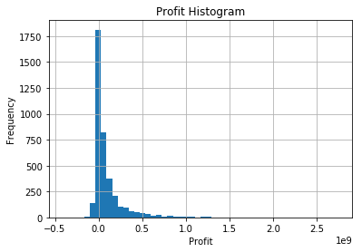

```python
ax = df.profit.hist(bins = 50);
ax.set_xlabel('Profit');
ax.set_ylabel('Frequency');
ax.set_title('Profit Histogram');
```

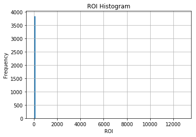

```python
ax = df.ROI.hist(bins = 100);
ax.set_xlabel('ROI');
ax.set_ylabel('Frequency');
ax.set_title('ROI Histogram');
```

It appears that profits are right-skewed, though not nearly as right-skewed as the ROIs. With the profits, increasing the granularity of the histogram by increasing the number of bins reveals the "bell", while even with 100 bins for ROIs, there isn't a visible bell, indicating the distribution is heavily skewed to the right.

While simply removing the outliers might reveal a curve, I do think keeping the outliers would be worthwhile given that I confirmed that the max ROIs remaining in the dataset were legitimate values.

Also, given that an ROI cannot be less than -1, adding 1 to the ROIs and then taking the log of the values might yield a transformed distribution more amenable to multivariable analysis.

```python
df['ROI_log'] = np.log(df['ROI'] + 1)
```

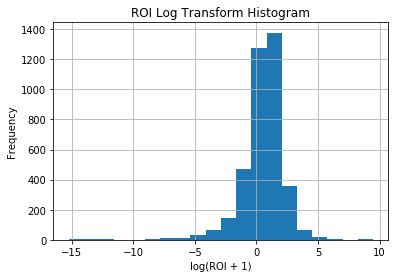

```python
ax = df.ROI_log.hist(bins = 20);
ax.set_xlabel('log(ROI + 1)');
ax.set_ylabel('Frequency');
ax.set_title('ROI Log Transform Histogram');
```

It does appear that the log transform addressed the skew, and thus potentially addresses the max values from being over-weighted in the mutlivariable analysis. Therefore, I will keep the log transformation in the dataframe.

After reordering the columns so all the financial figures are together, I will explore the correlations in dataset.

```python
df.columns
```

```
Index(['original_title', 'runtime', 'vote_count', 'vote_average',
       'release_year', 'budget_adj', 'revenue_adj', 'profit', 'ROI', 'Action',
       'Adventure', 'Animation', 'Comedy', 'Crime', 'Documentary', 'Drama',
       'Family', 'Fantasy', 'Foreign', 'History', 'Horror', 'Music', 'Mystery',
       'Romance', 'Science Fiction', 'TV Movie', 'Thriller', 'War', 'Western',
       'ROI_log'],
      dtype='object')
```

```python
df = df[['original_title', 'runtime', 'vote_count', 'vote_average',
       'release_year', 'budget_adj', 'revenue_adj', 'profit', 'ROI', 'ROI_log','Action',
       'Adventure', 'Animation', 'Comedy', 'Crime', 'Documentary', 'Drama',
       'Family', 'Fantasy', 'Foreign', 'History', 'Horror', 'Music', 'Mystery',
       'Romance', 'Science Fiction', 'TV Movie', 'Thriller', 'War', 'Western']]
```

## Exploratory Data Analysis

This section will detail the exploration of the cleaned dataset with a focus on correlations involving the financial figures.

### Exploring Correlations

In this section, I will calculate and review correlations amongst the fields in the dataset.

To begin, I will compute the correlation table and display sections of the table as heatmaps to highlight the significant correlations.

```python
# calculate and display correlation tables
corr_table = df.corr()
```

```python
corr_table.head()
```

|  | runtime | vote_count | vote_average | release_year | budget_adj | revenue_adj | profit | ROI | ROI_log | Action | ... | History | Horror | Music | Mystery | Romance | Science Fiction | TV Movie | Thriller | War | Western |
| --- | --- | --- | --- | --- | --- | --- | --- | --- | --- | --- | --- | --- | --- | --- | --- | --- | --- | --- | --- | --- | --- |
| runtime | 1.000000 | 0.274105 | 0.356631 | -0.114679 | 0.333914 | 0.280886 | 0.235713 | -0.034603 | 0.061045 | 0.075321 | ... | 0.310122 | -0.188609 | 0.000684 | 0.044570 | 0.029458 | -0.017181 | -0.016469 | 0.003022 | 0.196485 | 0.103776 |
| vote_count | 0.274105 | 1.000000 | 0.387669 | 0.206901 | 0.497735 | 0.654668 | 0.614122 | 0.004448 | 0.255727 | 0.196691 | ... | -0.023938 | -0.087976 | -0.053574 | -0.012508 | -0.095312 | 0.197708 | -0.009032 | 0.014913 | 0.007142 | 0.002674 |
| vote_average | 0.356631 | 0.387669 | 1.000000 | -0.134005 | 0.037048 | 0.267354 | 0.289155 | 0.006146 | 0.278582 | -0.103636 | ... | 0.096159 | -0.212518 | 0.035554 | 0.010649 | 0.013962 | -0.070469 | -0.011511 | -0.086446 | 0.094088 | 0.044093 |
| release_year | -0.114679 | 0.206901 | -0.134005 | 1.000000 | 0.074338 | -0.103455 | -0.132355 | -0.005355 | -0.184875 | -0.031612 | ... | -0.050332 | -0.052649 | -0.042442 | -0.013646 | -0.007903 | -0.046118 | -0.007537 | 0.001292 | -0.052902 | -0.081851 |
| budget_adj | 0.333914 | 0.497735 | 0.037048 | 0.074338 | 1.000000 | 0.570465 | 0.404447 | -0.031588 | 0.041255 | 0.310107 | ... | 0.052316 | -0.173732 | -0.038844 | -0.013490 | -0.104908 | 0.188401 | -0.013435 | 0.005039 | 0.051747 | 0.059808 |

5 rows × 29 columns

For the first heatmap, I will display the covaraiance amongst the continuous (non-genre/binary) variables.

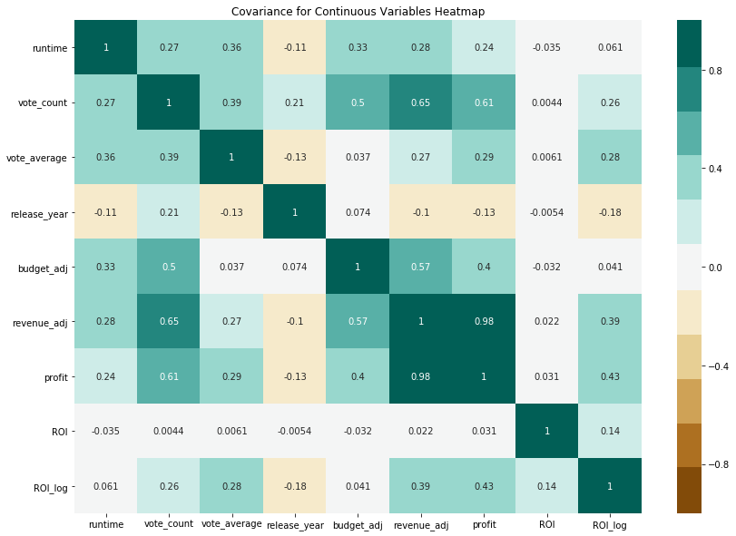

```python
# heatmap for covariance among continuous variables
cont_corr_table = corr_table.loc['runtime':'ROI_log','runtime':'ROI_log']
plt.pyplot.figure(figsize = (14,10))
plt.pyplot.title('Covariance for Continuous Variables Heatmap')
sns.heatmap(cont_corr_table, vmin = -1, center = 0, vmax = 1, annot=True, cmap = sns.color_palette("BrBG", 11));
```

It appears that `profit` and `roi_log` returned a number of significant correlations. Given all the variables are continuous, I will generate a scatter matrix of all the variables.

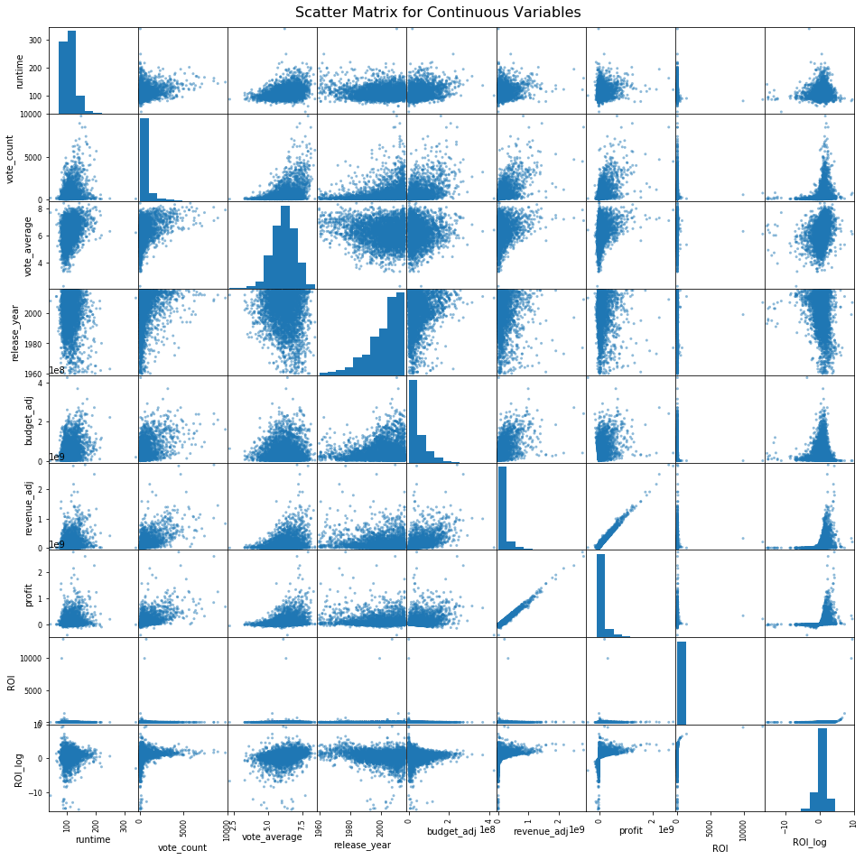

```python
pd.plotting.scatter_matrix(df.loc[:,'runtime':'ROI_log'], figsize = (16,16));
plt.pyplot.suptitle('Scatter Matrix for Continuous Variables', y = .9, fontsize = 16);
```

Focusing primarily on the bottom three rows of the matrix with the financial metrics, it does appear that generally the scatter plots reflect the correlation values. For example, the `profit` and `ROI_log` rows show several apparent linear relationships between the variables, while `ROI` doesn't appear to illustrate a correlation.

For the next heatmap, I will display the correlation amongst the continuous and binary fields.

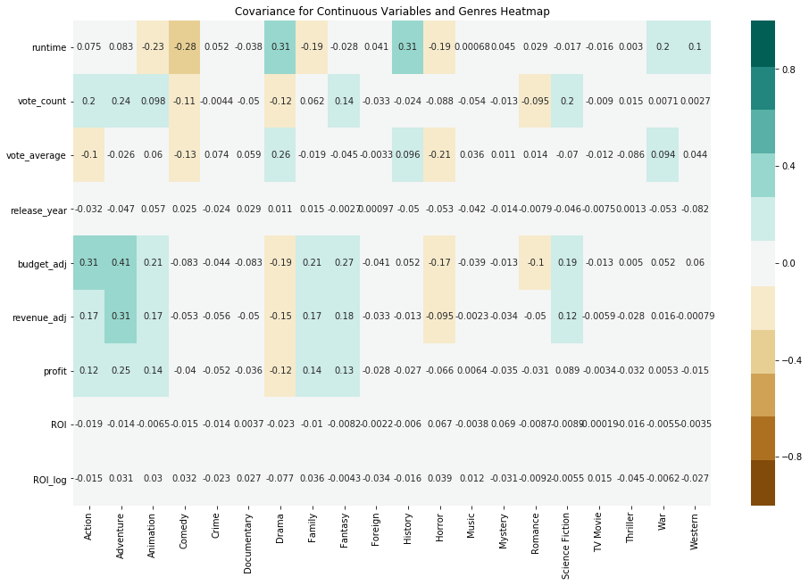

```python
# heatmap for covariance among continous variables and the binary genre fields
genre_corr_table = corr_table.loc['runtime':'ROI_log','Action':]
plt.pyplot.figure(figsize = (16,10))
plt.pyplot.title('Covariance for Continuous Variables and Genres Heatmap')
sns.heatmap(genre_corr_table, vmin = -1, center = 0, vmax = 1, annot=True, cmap = sns.color_palette("BrBG", 11));
```

In this case, it appears there are several significant covariances for the profit field and there are none for either of the ROI metrics.

Of the genres, it the `profit`-`Adventure` covariance is the greatest absolute value.

I will generate a density plot for Adventure and "non-Adventure" profit values to compare the distribution and see if the positive correlation does seem to accurately indicate adventure movies generating larger profits.

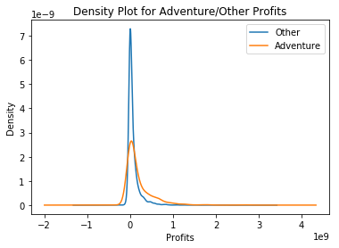

```python
ax = df[df.Adventure == 0].profit.plot.density();
df[df.Adventure == 1].profit.plot.density(ax = ax).legend(['Other','Adventure']);
ax.set_title('Density Plot for Adventure/Other Profits');
ax.set_xlabel('Profits');
```

With the density plot, it does appear that the Adventure profits have a fatter right tail. I will now generate the the box-and-whisker plots to compare the means and quartiles of the distributions.

```python
df[df.Adventure == 0].profit.describe()
```

```
count    3.102000e+03
mean     6.938694e+07
std      1.427800e+08
min     -1.375868e+08
25%     -2.180769e+06
50%      2.200037e+07
75%      8.666999e+07
max      2.234714e+09
Name: profit, dtype: float64
```

```python
df[df.Adventure == 1].profit.describe()
```

```
count    7.480000e+02
mean     1.900998e+08
std      3.128001e+08
min     -4.139124e+08
25%      2.434290e+06
50%      7.020676e+07
75%      2.598889e+08
max      2.750137e+09
Name: profit, dtype: float64
```

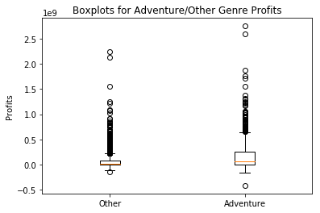

```python
plt.pyplot.boxplot((df[df.Adventure == 0].profit, df[df.Adventure == 1].profit), labels = ['Other', 'Adventure']);
plt.pyplot.title('Boxplots for Adventure/Other Genre Profits');
plt.pyplot.ylabel('Profits');
```

It does generally appear that the Adventure movies generate larger profits.

While the genres didn't reveal a significant covariance for the ROI metrics, perhaps particular combinations of genres would reveal a significant covariance.

The `genre`-`genre` covariance section of the correlation table does provide some interesting information about commonality of particular combinations of genres.

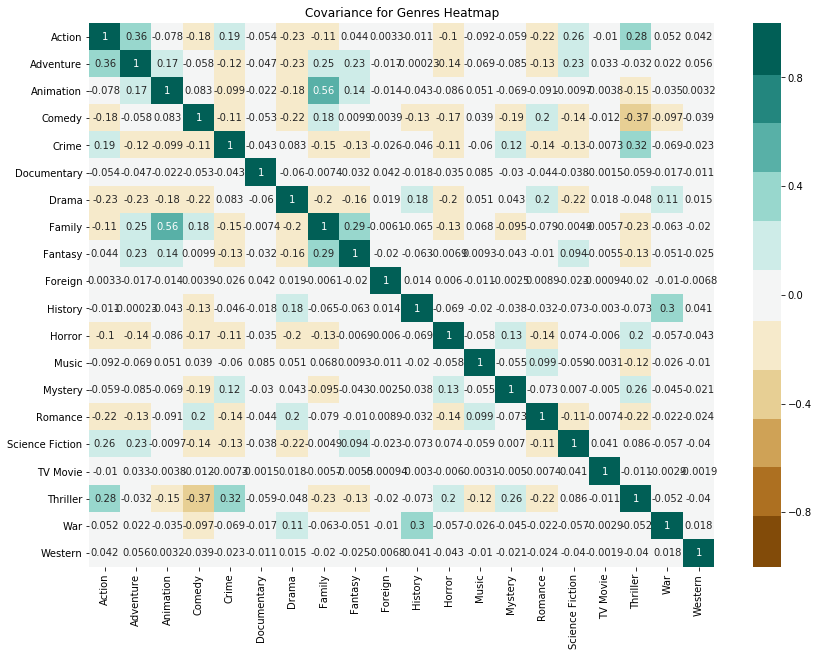

```python
genre_corr_table = corr_table.loc['Action':,'Action':]
plt.pyplot.figure(figsize = (14,10))
plt.pyplot.title('Covariance for Genres Heatmap')
sns.heatmap(genre_corr_table, vmin = -1, center = 0, vmax = 1, annot=True, cmap = sns.color_palette("BrBG", 11));
```

From reviewing the heatmap of the covariances, a lot of the significant covariances are intuitive. For example, adventure movies do seem to also be adventure movies, and animation movies also seem to tend to be family films.

I do think it would be interesting explore every permutation of genres to see if a particular combination seems to be profitable. I think in a more complex analysis (probably beyond the scope of this report) it might be worthwhile to fully explore the genres, given that the genre could potentially be a powerful predictor as the genre of the movie is decided early on in the movie production process, while something like review scores don't come until the movie is already produced.

### Summary of Exploration

From the exploration of the fields, there are three main considerations:

- The ROI metric in its original essentially failed to yield any signicant correlations
- The log transform of the ROI and profit both yielded many correlations amongst the continuous variables
- Only the profit metric yielded correlations with the genres

When reviewing the continuous variables, generating the scatter plots helped confirm the correlations calculated in the correlation table.

When reviewing the genres, using the adventure genre as a test, reviewing the distribution of adventure and non-adventure profits did seem support the significant covariance value shown in the heatmap.

## Conclusions

Given there were a number of significant correlations found for both the continuous variables and the genres, I am most comfortable with saying that among the financial metrics, the profit metric is ready for a rudimentary model for multivariate regression analysis.

I believe that the profit field is most ready given that there were significant correlations for genres, and I think the genres have more predictive power than the other fields given that the genre for a movie is determined early on in the movie production process, and thus there is less concern with the nature of the causality in the relationship between profit and genre.

### Limitations and Further Considerations

While for the profit metric I think there may be enough features to draft a predictive model, I do think that for all the potential dependent variables, the dataset should be mined further with advanced techniques to generate more features.

For example, it might be worthwhile to further explore combinations of genres since that could increase the number of genre features. Additionally, perhaps with more advanced techniques, it would be worthwhile to explore the cast, director, and production movie fields, because, like genres, those traits are determined early in the movie production process. Also, exploring those text fields could potentially vastly increase the number of predictive features and could comprise a complex and powerful model.